# Table of Contents

Le but de ce notebook est d'explorer différentes techniques permettant la labellisation automatique de questions posées sur le site StackOverflow.

# Importations et fonctions

Importation des librairies et déclaration des fonctions utilisées dans le notebook

```python
!pip install scikit-optimize
!pip install pyldavis

import pandas as pd
import os, glob, re, warnings, string
from bs4 import BeautifulSoup
from skopt import BayesSearchCV
import nltk
from nltk.corpus import stopwords, wordnet
from nltk.stem import WordNetLemmatizer
from multiprocessing import Pool
from sklearn.model_selection import train_test_split
from gensim import corpora, models
from sklearn.linear_model import LogisticRegression, LogisticRegressionCV
from sklearn.neural_network import MLPClassifier
from sklearn.svm import LinearSVC
from sklearn.metrics import accuracy_score, f1_score
from sklearn.multiclass import OneVsRestClassifier
from sklearn.preprocessing import MultiLabelBinarizer
from sklearn.feature_extraction.text import TfidfVectorizer
from sklearn.pipeline import Pipeline
from sklearn.model_selection import RandomizedSearchCV, ShuffleSplit
from xgboost import XGBClassifier
import matplotlib.pyplot as plt
import pickle
import gensim
import seaborn as sns
import random
import numpy as np
import pyLDAvis


import tensorflow as tf
from tensorflow.keras.preprocessing.text import Tokenizer
from tensorflow.keras.preprocessing.sequence import pad_sequences
from tensorflow.keras.initializers import he_uniform

import pyLDAvis.gensim
pyLDAvis.enable_notebook()

nltk.download('stopwords')
nltk.download('wordnet')
nltk.download('averaged_perceptron_tagger')
nltk.download('punkt')
warnings.filterwarnings('ignore')
stopw = stopwords.words("english") + ["i'm", "i've", "i'd", "i'll", "cant", "can", 'cannot']

df_stack = pickle.load(open('drive/My Drive/Colab Notebooks/OC/Projet 5/datasets/df_stack', 'rb'))
#df_stack = pickle.load(open('drive/My Drive/Colab Notebooks/OC/Projet 5/df_stack_tokenized', 'rb'))

def weighted_batch(X_train, y_train, X_test, y_test, min_weight=0, step=0.1, min_threshold=0.1, max_threshold=0.9):
  """
  Fonction pour déterminer le meilleur stacking des modèles prédictifs
  """
  len_x_train = len(X_train)
  best_scores = [[0, 0, 0, 0] for x in range(3)]

  best_scores = _rec_best_weights(X_train, y_train, X_test, y_test, best_scores, min_weight, step, cpt=len_x_train)

  return best_scores

def _best_scores_thresholds(x_train, y_train, x_test, y_test, prev_scores, list_weight, min_threshold=0.1, max_threshold=0.8):
  """
  Détermine le meilleur seuil pour la meilleure prédiction
  """
  for i in np.arange(min_threshold, max_threshold, 0.1):
      i = round(i, 2)
      x_train_thre = x_train.copy()
      x_test_thre = x_test.copy()
      x_train_thre[x_train_thre >= i] = 1
      x_train_thre[x_train_thre < i] = 0
      x_test_thre[x_test_thre >= i] = 1
      x_test_thre[x_test_thre < i] = 0
      acc_train_preds = accuracy_score(x_train_thre, y_train)
      acc_test_preds = accuracy_score(x_test_thre, y_test)
      f1_test_preds = f1_score(x_test_thre, y_test, average='micro')

      if acc_train_preds > prev_scores[0][1]:
        prev_scores[0][0] = (i,) + tuple(list_weight)
        prev_scores[0][1] = acc_train_preds
        prev_scores[0][2] = acc_test_preds
        prev_scores[0][3] = f1_test_preds
      if acc_test_preds > prev_scores[1][2]:
        prev_scores[1][0] = (i,) + tuple(list_weight)
        prev_scores[1][1] = acc_train_preds
        prev_scores[1][2] = acc_test_preds
        prev_scores[1][3] = f1_test_preds
      if f1_test_preds > prev_scores[2][3]:
        prev_scores[2][0] = (i,) + tuple(list_weight)
        prev_scores[2][1] = acc_train_preds
        prev_scores[2][2] = acc_test_preds
        prev_scores[2][3] = f1_test_preds

  return prev_scores

def _rec_best_weights(X_train, y_train, X_test, y_test, best_scores, min_weight=0, step=0.1, list_weight=[], cpt=0):
  """
  Méthode utilisée pour effectuer chaque combinaison possible de stacking
  """
  alpha = sum(list_weight)

  if cpt == 1:
      list_weight += [round(1-alpha, 2)]
      x_train = np.sum([w*l for w, l in zip(list_weight, X_train)], axis=0)
      x_test = np.sum([w*l for w, l in zip(list_weight, X_test)], axis=0)
      best_scores = _best_scores_thresholds(x_train, y_train, x_test, y_test, best_scores, list_weight)

      return best_scores
  else:
    cpt -= 1

    for beta in np.arange(min_weight, round(1 - alpha + step - min_weight, 2), step):
      beta = round(beta, 2)
      best_scores = _rec_best_weights(X_train, y_train, X_test, y_test, best_scores, min_weight, step, list_weight + [beta], cpt)

    return best_scores
```

Récupération des datasets

```python
PATH_FILES = 'drive/My Drive/Colab Notebooks/OC/Projet 5/datasets'
df = pd.concat(map(pd.read_csv, glob.glob(os.path.join('', PATH_FILES+ "/*.csv"))))
df.head()
```

|  | Id | PostTypeId | AcceptedAnswerId | ParentId | CreationDate | DeletionDate | Score | ViewCount | Body | OwnerUserId | OwnerDisplayName | LastEditorUserId | LastEditorDisplayName | LastEditDate | LastActivityDate | Title | Tags | AnswerCount | CommentCount | FavoriteCount | ClosedDate | CommunityOwnedDate | ContentLicense |
| --- | --- | --- | --- | --- | --- | --- | --- | --- | --- | --- | --- | --- | --- | --- | --- | --- | --- | --- | --- | --- | --- | --- | --- |
| 0 | 62185373 | 1 | 62193329.0 | NaN | 2020-06-04 01:26:07 | NaN | 58 | 5546 | <p>Consider this code:</p>\n\n<pre><code>int i... | 13563520.0 | NaN | 12121627.0 | NaN | 2020-06-06 03:21:49 | 2020-06-06 19:09:39 | In practice, why would different compilers com... | <c++><undefined-behavior> | 10 | 5 | 13.0 | NaN | NaN | CC BY-SA 4.0 |
| 1 | 61992025 | 1 | NaN | NaN | 2020-05-24 20:24:52 | NaN | 13 | 2101 | <p>Recently i was working on a web design proj... | 5935306.0 | NaN | NaN | NaN | NaN | 2020-05-30 14:29:00 | Google Chrome showing black border on focus st... | <css><google-chrome><google-chrome-devtools> | 2 | 5 | 4.0 | NaN | NaN | CC BY-SA 4.0 |
| 2 | 61933862 | 1 | 61934324.0 | NaN | 2020-05-21 11:50:16 | NaN | 25 | 1408 | <p>Is it legal to access pointers to functions... | 2564696.0 | NaN | 1687119.0 | NaN | 2020-05-21 15:46:32 | 2020-05-22 09:33:57 | Using void (*)() pointers for other functions | <c><function><pointers><language-lawyer> | 3 | 5 | 10.0 | NaN | NaN | CC BY-SA 4.0 |
| 3 | 61815143 | 1 | NaN | NaN | 2020-05-15 08:39:35 | NaN | 24 | 2036 | <p>I am pretty sure that this error appeared o... | 13506128.0 | NaN | 5792209.0 | NaN | 2020-05-25 09:41:02 | 2020-05-26 20:04:14 | Denial of Service - http proxy - React | <reactjs><http-proxy><denial-of-service> | 3 | 6 | 9.0 | NaN | NaN | CC BY-SA 4.0 |
| 4 | 61736649 | 1 | 61736789.0 | NaN | 2020-05-11 18:26:17 | NaN | 52 | 2998 | <p>I have a legacy application that takes an i... | 3938965.0 | NaN | 224132.0 | NaN | 2020-05-14 18:44:10 | 2020-06-01 10:40:40 | In Java, how to get positions of ones in rever... | <java><bit-manipulation> | 13 | 10 | 4.0 | NaN | NaN | CC BY-SA 4.0 |

# Traitements

Nous allons conserver uniquement les titres, le corpus et les tags.

Pour améliorer nos modèles, les titres seront incorpérés au corpus en doublant leur apparition

```python
df_stack = df[['Title', 'Body', 'Tags']]
df_stack['Body'] = 2 * (df_stack['Title'] + " ") + df_stack['Body']
df_stack['Tags'] = df_stack['Tags'].apply(lambda x: x[1:-1].split("><"))
print(df_stack.head())
print(df_stack['Body'].iat[0])
```

```
                                               Title  ...                                          Tags
0  In practice, why would different compilers com...  ...                     [c++, undefined-behavior]
1  Google Chrome showing black border on focus st...  ...  [css, google-chrome, google-chrome-devtools]
2      Using void (*)() pointers for other functions  ...      [c, function, pointers, language-lawyer]
3             Denial of Service - http proxy - React  ...      [reactjs, http-proxy, denial-of-service]
4  In Java, how to get positions of ones in rever...  ...                      [java, bit-manipulation]

[5 rows x 3 columns]
In practice, why would different compilers compute different values of int x = ++i + ++i;? In practice, why would different compilers compute different values of int x = ++i + ++i;? <p>Consider this code:</p>

<pre><code>int i = 1;
int x = ++i + ++i;
</code></pre>

<p>We have some guesses for what a compiler might do for this code, assuming it compiles.</p>

<ol>
<li>both <code>++i</code> return <code>2</code>, resulting in <code>x=4</code>.</li>
<li>one <code>++i</code> returns <code>2</code> and the other returns <code>3</code>, resulting in <code>x=5</code>.</li>
<li>both <code>++i</code> return <code>3</code>, resulting in <code>x=6</code>.</li>
</ol>

<p>To me, the second seems most likely. One of the two <code>++</code> operators is executed with <code>i = 1</code>, the <code>i</code> is incremented, and the result <code>2</code> is returned. Then the second <code>++</code> operator is executed with <code>i = 2</code>, the <code>i</code> is incr…

<p>However, I ran this code in Visual Studio, and the result was <code>6</code>. I'm trying to understand compilers better, and I'm wondering what could possibly lead to a result of <code>6</code>. My only guess is that the code could be executed with some "built-in" concurrency. The two <code>++</c…

<p>My question is: what (reasonable) things could a <code>C++</code> compiler do that would lead to a result of <code>4</code> or a result or <code>6</code>?</p>
```

La lemmatisation est utilisée avec d'autres traitements :

- Elimination des tags HTLM, ponctuations
- Transformation des majuscules en minuscules
- Les ponctuations dans C++, C# sont conservés
- Les mots avec un seul mot sont supprimés sauf pour R et C

Le tout est fait avec de la parallélisation pour accélérer le temps de calcul

```python
punctuations = re.sub("[+#]", "", string.punctuation)
keep_letters = ["r", "c"]
stopw = list(set(stopw + [x.translate(str.maketrans("", "", "'")) for x in stopw]))

lemmatizer = WordNetLemmatizer()


def get_wordnet_pos(word):
    """
    Fonction employée pour la lemmatisation
    """
    tag = nltk.pos_tag([word])[0][1][0].upper()
    tag_dict = {"J": wordnet.ADJ,
                "N": wordnet.NOUN,
                "V": wordnet.VERB,
                "R": wordnet.ADV}

    return tag_dict.get(tag, wordnet.NOUN)

def txt_preprocessing(text):
    """
    Traitement ligne par ligne
    """
    text = BeautifulSoup(text, 'lxml').get_text()
    text = text.lower()
    text = text.translate(str.maketrans("", "", punctuations))
    text = re.sub("[^c]\+\+|[^\w+](\+|\#)[^\w+]|[\w"+string.punctuation+"]*\d[\w"+string.punctuation+"]*", " ", text)
    text = [w for w in text.split() if (len(w) > 1 or w in keep_letters) and w not in stopw]

    return [lemmatizer.lemmatize(x, get_wordnet_pos(x)) for x in text]

with Pool() as pool:
    df_stack['Body'] = pool.map(txt_preprocessing, df_stack['Body'])
```

Voici l'exemple précédent après les traitements.

```python
print(df_stack['Body'].iat[0])
```

```
['practice', 'would', 'different', 'compiler', 'compute', 'different', 'value', 'int', '++i', 'practice', 'would', 'different', 'compiler', 'compute', 'different', 'value', 'int', '++i', 'consider', 'code', 'int', 'int', '++i', 'guess', 'compiler', 'might', 'code', 'assume', 'compiles', 'return', 'r…
```

Les mots inutiles sont bien retirés, les chiffres également, etc.

# LDA

Pour le LDA, nous allons commencer avec des sacs de mots en conservant uniquement les 20 000 mots les plus fréquents et ceux qui apparaissent au moins 10 fois.

```python
dictionary = gensim.corpora.Dictionary(df_stack['Body'])
dictionary.filter_extremes(no_below=10, keep_n=20000)
bow_corpus = [dictionary.doc2bow(doc) for doc in df_stack['Body']]
tfidf = models.TfidfModel(bow_corpus)
corpus_tfidf = tfidf[bow_corpus]
bow_corpus[0][:5]
```

```
[(0, 1), (1, 1), (2, 1), (3, 1), (4, 1)]
```

Pour déterminer le nombre de sujets optimal à conserver, vous allons utiliser le score de cohérence.

Dus aux temps d'exécution, nous n'allons explore que sur 50, 100, 150 et 200 sujets.

```python
coherence_values = []
range_topics = [50, 100, 150, 200]
for num_topics in range_topics:
    model = gensim.models.LdaMulticore(bow_corpus, num_topics=num_topics, id2word=dictionary, random_state=1)
    coherencemodel = gensim.models.CoherenceModel(model=model, texts=df_stack['Body'], dictionary=dictionary, coherence='c_v')
    coherence_values.append(coherencemodel.get_coherence())
```

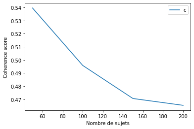

```python
plt.plot(range_topics, coherence_values)
plt.xlabel("Nombre de sujets")
plt.ylabel("Coherence score")
plt.legend(("coherence_values"), loc='best')
plt.show()
```

Nous observons que le score de cohérence est le plus élevé lors que nous utilisons que 50 sujets.

Nous allons donc garder cette valeur pour le LDA utilisant le sac de mots.

```python
lda_model = gensim.models.LdaMulticore(bow_corpus, num_topics=50, id2word=dictionary, random_state=1)
for idx, topic in lda_model.print_topics(-1):
    print('Topic: {} - Words: {}'.format(idx, topic))
```

```
Topic: 0 - Words: 0.046*"version" + 0.035*"error" + 0.026*"studio" + 0.025*"package" + 0.025*"instal" + 0.022*"visual" + 0.021*"install" + 0.019*"warn" + 0.018*"debug" + 0.015*"run"
Topic: 1 - Words: 0.061*"git" + 0.043*"remote" + 0.028*"push" + 0.026*"repository" + 0.025*"merge" + 0.025*"branch" + 0.024*"commit" + 0.021*"master" + 0.020*"change" + 0.017*"tag"
Topic: 2 - Words: 0.145*"class" + 0.073*"object" + 0.047*"method" + 0.026*"public" + 0.018*"instance" + 0.018*"call" + 0.015*"void" + 0.014*"constructor" + 0.013*"error" + 0.013*"return"
Topic: 3 - Words: 0.032*"core" + 0.025*"net" + 0.024*"new" + 0.023*"aspnet" + 0.021*"public" + 0.021*"get" + 0.020*"c#" + 0.016*"service" + 0.016*"web" + 0.015*"application"
Topic: 4 - Words: 0.045*"button" + 0.027*"click" + 0.023*"item" + 0.016*"tab" + 0.015*"event" + 0.014*"change" + 0.013*"bar" + 0.013*"scroll" + 0.012*"want" + 0.012*"menu"
Topic: 5 - Words: 0.137*"var" + 0.050*"key" + 0.037*"function" + 0.027*"new" + 0.019*"return" + 0.017*"ajax" + 0.015*"const" + 0.015*"code" + 0.015*"data" + 0.014*"error"
Topic: 6 - Words: 0.092*"dependency" + 0.030*"plugin" + 0.024*"log" + 0.024*"build" + 0.022*"configuration" + 0.018*"jenkins" + 0.015*"error" + 0.014*"project" + 0.014*"ionic" + 0.013*"maven"
Topic: 7 - Words: 0.058*"spring" + 0.035*"bean" + 0.026*"django" + 0.025*"boot" + 0.023*"class" + 0.015*"exception" + 0.014*"nest" + 0.013*"application" + 0.011*"create" + 0.011*"return"
Topic: 8 - Words: 0.076*"column" + 0.036*"dataframe" + 0.032*"panda" + 0.029*"data" + 0.024*"row" + 0.023*"group" + 0.022*"spark" + 0.019*"order" + 0.017*"value" + 0.016*"df"
Topic: 9 - Words: 0.104*"public" + 0.084*"new" + 0.083*"string" + 0.067*"null" + 0.035*"return" + 0.030*"void" + 0.027*"get" + 0.023*"static" + 0.022*"set" + 0.021*"class"
Topic: 10 - Words: 0.107*"array" + 0.046*"loop" + 0.033*"print" + 0.018*"element" + 0.017*"double" + 0.016*"nan" + 0.015*"value" + 0.014*"count" + 0.012*"dictionary" + 0.012*"like"
Topic: 11 - Words: 0.077*"request" + 0.043*"response" + 0.030*"header" + 0.027*"http" + 0.026*"post" + 0.021*"get" + 0.020*"url" + 0.020*"api" + 0.020*"send" + 0.017*"call"
Topic: 12 - Words: 0.049*"server" + 0.037*"message" + 0.026*"client" + 0.024*"notification" + 0.019*"firebase" + 0.017*"certificate" + 0.014*"root" + 0.012*"ssl" + 0.011*"send" + 0.009*"host"
Topic: 13 - Words: 0.178*"text" + 0.048*"native" + 0.024*"screen" + 0.021*"react" + 0.020*"share" + 0.014*"reactnative" + 0.014*"facebook" + 0.013*"game" + 0.012*"app" + 0.010*"user"
Topic: 14 - Words: 0.037*"map" + 0.031*"page" + 0.029*"browser" + 0.027*"chrome" + 0.020*"work" + 0.019*"load" + 0.019*"location" + 0.016*"url" + 0.015*"get" + 0.013*"javascript"
Topic: 15 - Words: 0.082*"table" + 0.034*"row" + 0.028*"column" + 0.024*"td" + 0.023*"tr" + 0.020*"insert" + 0.020*"value" + 0.015*"data" + 0.015*"select" + 0.013*"excel"
Topic: 16 - Words: 0.210*"file" + 0.020*"save" + 0.020*"read" + 0.019*"upload" + 0.018*"csv" + 0.017*"download" + 0.016*"data" + 0.014*"document" + 0.014*"xml" + 0.013*"filename"
Topic: 17 - Words: 0.073*"database" + 0.061*"php" + 0.035*"laravel" + 0.031*"mysql" + 0.022*"echo" + 0.020*"delete" + 0.018*"error" + 0.018*"db" + 0.016*"page" + 0.015*"update"
Topic: 18 - Words: 0.126*"function" + 0.054*"variable" + 0.030*"value" + 0.019*"property" + 0.019*"call" + 0.019*"check" + 0.018*"like" + 0.018*"undefined" + 0.016*"pas" + 0.015*"way"
Topic: 19 - Words: 0.120*"line" + 0.087*"file" + 0.048*"python" + 0.035*"module" + 0.028*"error" + 0.015*"last" + 0.014*"call" + 0.014*"run" + 0.013*"recent" + 0.013*"try"
Topic: 20 - Words: 0.131*"div" + 0.033*"html" + 0.019*"script" + 0.015*"cs" + 0.014*"li" + 0.013*"body" + 0.012*"span" + 0.012*"element" + 0.011*"display" + 0.011*"style"
Topic: 21 - Words: 0.053*"android" + 0.036*"compile" + 0.026*"gradle" + 0.026*"implementation" + 0.024*"na" + 0.021*"apply" + 0.021*"font" + 0.014*"studio" + 0.013*"plugin" + 0.012*"dependency"
Topic: 22 - Words: 0.071*"input" + 0.061*"form" + 0.031*"field" + 0.030*"value" + 0.027*"select" + 0.026*"option" + 0.021*"label" + 0.015*"div" + 0.014*"button" + 0.013*"typetext"
Topic: 23 - Words: 0.050*"command" + 0.048*"script" + 0.040*"run" + 0.033*"window" + 0.020*"file" + 0.017*"directory" + 0.017*"error" + 0.014*"try" + 0.013*"get" + 0.012*"execute"
Topic: 24 - Words: 0.041*"npm" + 0.039*"connection" + 0.036*"run" + 0.033*"server" + 0.030*"error" + 0.029*"connect" + 0.024*"err" + 0.022*"start" + 0.021*"install" + 0.018*"fail"
Topic: 25 - Words: 0.044*"byte" + 0.044*"character" + 0.039*"word" + 0.036*"stream" + 0.030*"string" + 0.017*"encode" + 0.015*"length" + 0.015*"transaction" + 0.013*"try" + 0.012*"replace"
Topic: 26 - Words: 0.090*"public" + 0.085*"private" + 0.033*"return" + 0.026*"property" + 0.026*"void" + 0.025*"entity" + 0.024*"class" + 0.024*"string" + 0.016*"long" + 0.014*"boolean"
Topic: 27 - Words: 0.061*"exception" + 0.049*"error" + 0.039*"task" + 0.023*"process" + 0.017*"method" + 0.016*"message" + 0.016*"stack" + 0.015*"handle" + 0.015*"throw" + 0.015*"call"
Topic: 28 - Words: 0.155*"name" + 0.060*"python" + 0.055*"def" + 0.047*"model" + 0.017*"none" + 0.015*"get" + 0.010*"age" + 0.009*"code" + 0.009*"country" + 0.009*"attribute"
Topic: 29 - Words: 0.037*"c" + 0.035*"int" + 0.029*"memory" + 0.028*"#include" + 0.023*"char" + 0.019*"size" + 0.016*"program" + 0.012*"main" + 0.012*"struct" + 0.011*"pointer"
Topic: 30 - Words: 0.091*"app" + 0.049*"io" + 0.024*"work" + 0.021*"xcode" + 0.018*"icon" + 0.012*"device" + 0.011*"show" + 0.010*"try" + 0.010*"iphone" + 0.009*"issue"
Topic: 31 - Words: 0.034*"docker" + 0.032*"password" + 0.027*"user" + 0.026*"email" + 0.025*"container" + 0.017*"run" + 0.017*"username" + 0.014*"port" + 0.013*"host" + 0.011*"ip"
Topic: 32 - Words: 0.490*"import" + 0.035*"video" + 0.016*"pdf" + 0.016*"path" + 0.015*"export" + 0.013*"player" + 0.012*"play" + 0.011*"module" + 0.010*"package" + 0.009*"class"
```

[output cut: 17 more lines]

Nous pouvons visualiser la corrélation entre les sujets grâce à la librairie pyLDAvis qui va effectuer une ACP.

```python
ldavis_bow = pyLDAvis.gensim.prepare(lda_model, bow_corpus, dictionary=lda_model.id2word)
ldavis_bow
```

[interactive chart not shown]

```python
lda_model_tfidf = gensim.models.LdaMulticore(corpus_tfidf, num_topics=100, id2word=dictionary, random_state=1)
for idx, topic in lda_model_tfidf.print_topics(-1):
    print('Topic: {} - Words: {}'.format(idx, topic))
```

```
Topic: 0 - Words: 0.035*"swift" + 0.025*"let" + 0.019*"func" + 0.012*"nil" + 0.010*"io" + 0.009*"view" + 0.008*"var" + 0.008*"xcode" + 0.006*"controller" + 0.006*"swagger"
Topic: 1 - Words: 0.031*"angular" + 0.022*"typescript" + 0.016*"mock" + 0.012*"test" + 0.012*"ng" + 0.010*"heroku" + 0.010*"material" + 0.009*"import" + 0.008*"module" + 0.008*"component"
Topic: 2 - Words: 0.040*"regex" + 0.031*"recyclerview" + 0.018*"adapter" + 0.016*"item" + 0.015*"public" + 0.013*"view" + 0.012*"match" + 0.012*"listview" + 0.010*"override" + 0.010*"viewholder"
Topic: 3 - Words: 0.040*"npm" + 0.018*"err" + 0.017*"pod" + 0.015*"ssh" + 0.012*"node" + 0.012*"install" + 0.010*"run" + 0.009*"error" + 0.008*"command" + 0.008*"kubernetes"
Topic: 4 - Words: 0.024*"price" + 0.012*"quantity" + 0.011*"weight" + 0.008*"callable" + 0.008*"jq" + 0.007*"objectid" + 0.006*"iso" + 0.005*"json" + 0.005*"fruit" + 0.005*"value"
Topic: 5 - Words: 0.015*"score" + 0.009*"regression" + 0.009*"sklearn" + 0.008*"xaxis" + 0.008*"model" + 0.007*"dataset" + 0.007*"metric" + 0.007*"data" + 0.007*"predict" + 0.007*"thissetstate"
Topic: 6 - Words: 0.037*"selenium" + 0.016*"webdriver" + 0.015*"chrome" + 0.014*"bucket" + 0.014*"driver" + 0.011*"firefox" + 0.008*"uwp" + 0.008*"browser" + 0.008*"nuget" + 0.007*"pi"
Topic: 7 - Words: 0.018*"substring" + 0.017*"distinct" + 0.013*"ddmmyyyy" + 0.013*"twig" + 0.011*"criterion" + 0.010*"underline" + 0.010*"aggregation" + 0.010*"unique" + 0.010*"listbox" + 0.010*"innodb"
Topic: 8 - Words: 0.039*"tab" + 0.029*"qt" + 0.017*"round" + 0.010*"sender" + 0.010*"eventargs" + 0.009*"tablayout" + 0.009*"mssql" + 0.009*"partial" + 0.008*"corner" + 0.007*"delimit"
Topic: 9 - Words: 0.018*"websocket" + 0.014*"cluster" + 0.013*"kubernetes" + 0.011*"linq" + 0.010*"ip" + 0.009*"connection" + 0.008*"port" + 0.008*"server" + 0.008*"tcp" + 0.007*"service"
Topic: 10 - Words: 0.040*"sum" + 0.027*"realm" + 0.019*"soap" + 0.016*"nameerror" + 0.015*"openssl" + 0.015*"scrollbar" + 0.012*"mismatch" + 0.011*"probability" + 0.011*"userdata" + 0.010*"starttime"
Topic: 11 - Words: 0.032*"enum" + 0.015*"junit" + 0.014*"rds" + 0.013*"pytest" + 0.012*"test" + 0.012*"mask" + 0.012*"thumbnail" + 0.011*"jersey" + 0.009*"public" + 0.008*"connector"
Topic: 12 - Words: 0.039*"email" + 0.016*"mail" + 0.015*"send" + 0.012*"firstname" + 0.011*"lastname" + 0.011*"contact" + 0.010*"address" + 0.009*"proxy" + 0.009*"phone" + 0.008*"smtp"
Topic: 13 - Words: 0.051*"dependency" + 0.034*"azure" + 0.022*"maven" + 0.018*"intellij" + 0.016*"plugin" + 0.013*"info" + 0.013*"project" + 0.013*"jar" + 0.010*"configuration" + 0.010*"execution"
Topic: 14 - Words: 0.027*"socket" + 0.022*"th" + 0.016*"tbody" + 0.015*"scanner" + 0.014*"socketio" + 0.013*"client" + 0.011*"server" + 0.009*"gpu" + 0.009*"movie" + 0.009*"slide"
Topic: 15 - Words: 0.035*"div" + 0.019*"width" + 0.019*"color" + 0.018*"height" + 0.017*"cs" + 0.013*"scroll" + 0.012*"background" + 0.011*"style" + 0.011*"center" + 0.011*"image"
Topic: 16 - Words: 0.040*"column" + 0.038*"dataframe" + 0.034*"panda" + 0.020*"csv" + 0.019*"row" + 0.015*"df" + 0.013*"value" + 0.010*"data" + 0.008*"decimal" + 0.008*"frame"
Topic: 17 - Words: 0.027*"wordpress" + 0.022*"schema" + 0.015*"txt" + 0.013*"mongoose" + 0.011*"file" + 0.007*"parquet" + 0.006*"word" + 0.006*"pickle" + 0.005*"type" + 0.005*"string"
Topic: 18 - Words: 0.028*"audio" + 0.018*"vscode" + 0.016*"play" + 0.011*"gitlab" + 0.008*"cpu" + 0.007*"sound" + 0.007*"video" + 0.006*"headless" + 0.006*"arm" + 0.006*"atom"
Topic: 19 - Words: 0.031*"line" + 0.027*"python" + 0.026*"module" + 0.026*"file" + 0.022*"import" + 0.017*"install" + 0.016*"pip" + 0.013*"traceback" + 0.012*"recent" + 0.011*"importerror"
Topic: 20 - Words: 0.036*"div" + 0.025*"input" + 0.024*"form" + 0.022*"button" + 0.017*"select" + 0.013*"dropdown" + 0.012*"option" + 0.011*"click" + 0.010*"value" + 0.010*"typetext"
Topic: 21 - Words: 0.027*"drive" + 0.021*"longitude" + 0.021*"latitude" + 0.018*"cloudformation" + 0.016*"cognito" + 0.015*"stdout" + 0.015*"player" + 0.012*"arr" + 0.012*"intellisense" + 0.012*"stderr"
Topic: 22 - Words: 0.023*"thread" + 0.016*"queue" + 0.010*"lock" + 0.009*"worker" + 0.007*"wait" + 0.007*"process" + 0.006*"task" + 0.006*"parallel" + 0.006*"gson" + 0.006*"slice"
Topic: 23 - Words: 0.054*"font" + 0.018*"hex" + 0.012*"language" + 0.011*"rgb" + 0.009*"awesome" + 0.009*"scope" + 0.008*"rstudio" + 0.008*"english" + 0.008*"expressjs" + 0.008*"leak"
Topic: 24 - Words: 0.042*"django" + 0.015*"widget" + 0.013*"model" + 0.012*"comma" + 0.012*"def" + 0.010*"class" + 0.009*"field" + 0.009*"import" + 0.009*"child" + 0.008*"flutter"
Topic: 25 - Words: 0.063*"date" + 0.021*"datetime" + 0.020*"format" + 0.018*"month" + 0.014*"day" + 0.014*"timestamp" + 0.012*"convert" + 0.012*"time" + 0.011*"year" + 0.009*"string"
```

[output cut: 74 more lines]

```python
ldavis_tfidf = pyLDAvis.gensim.prepare(lda_model_tfidf, corpus_tfidf, dictionary=lda_model.id2word)
ldavis_tfidf
```

```
Output hidden; open in https://colab.research.google.com to view.
```

```python
i = 0
print(df_stack['Tags'].iat[i])
print(df['Title'].iat[i])
print(df['Body'].iat[i])
print('----\nBoW')
for index, score in sorted(lda_model[bow_corpus[i]], key=lambda tup: -1*tup[1]):
    print("Score: {}\t \nTopic {}: {}".format(score, index, lda_model.print_topic(index, 10)))
print('----\nTF-IDF')
for index, score in sorted(lda_model_tfidf[bow_corpus[i]], key=lambda tup: -1*tup[1]):
    print("Score: {}\t \nTopic {}: {}".format(score, index, lda_model_tfidf.print_topic(index, 10)))
```

```
['c++']
In practice, why would different compilers compute different values of int x = ++i + ++i;?
<p>Consider this code:</p>

<pre><code>int i = 1;
int x = ++i + ++i;
</code></pre>

<p>We have some guesses for what a compiler might do for this code, assuming it compiles.</p>

<ol>
<li>both <code>++i</code> return <code>2</code>, resulting in <code>x=4</code>.</li>
<li>one <code>++i</code> returns <code>2</code> and the other returns <code>3</code>, resulting in <code>x=5</code>.</li>
<li>both <code>++i</code> return <code>3</code>, resulting in <code>x=6</code>.</li>
</ol>

<p>To me, the second seems most likely. One of the two <code>++</code> operators is executed with <code>i = 1</code>, the <code>i</code> is incremented, and the result <code>2</code> is returned. Then the second <code>++</code> operator is executed with <code>i = 2</code>, the <code>i</code> is incr…

<p>However, I ran this code in Visual Studio, and the result was <code>6</code>. I'm trying to understand compilers better, and I'm wondering what could possibly lead to a result of <code>6</code>. My only guess is that the code could be executed with some "built-in" concurrency. The two <code>++</c…

<p>My question is: what (reasonable) things could a <code>C++</code> compiler do that would lead to a result of <code>4</code> or a result or <code>6</code>?</p>

----
BoW
Score: 0.6308541297912598
Topic 46: 0.017*"code" + 0.015*"would" + 0.015*"question" + 0.012*"like" + 0.010*"one" + 0.010*"way" + 0.010*"work" + 0.008*"example" + 0.008*"seem" + 0.008*"know"
Score: 0.29994335770606995
Topic 49: 0.065*"list" + 0.043*"int" + 0.035*"return" + 0.032*"value" + 0.016*"number" + 0.016*"else" + 0.015*"point" + 0.014*"two" + 0.014*"float" + 0.014*"case"
Score: 0.03313296660780907
Topic 27: 0.061*"exception" + 0.049*"error" + 0.039*"task" + 0.023*"process" + 0.017*"method" + 0.016*"message" + 0.016*"stack" + 0.015*"handle" + 0.015*"throw" + 0.015*"call"
Score: 0.02686949260532856
Topic 0: 0.046*"version" + 0.035*"error" + 0.026*"studio" + 0.025*"package" + 0.025*"instal" + 0.022*"visual" + 0.021*"install" + 0.019*"warn" + 0.018*"debug" + 0.015*"run"
----
TF-IDF
Score: 0.6002697944641113
Topic 35: 0.024*"int" + 0.022*"#include" + 0.020*"c++" + 0.017*"char" + 0.011*"struct" + 0.010*"c" + 0.010*"cout" + 0.009*"vector" + 0.008*"pointer" + 0.008*"function"
Score: 0.24819040298461914
Topic 59: 0.020*"golang" + 0.014*"distance" + 0.012*"counter" + 0.010*"pair" + 0.009*"err" + 0.007*"func" + 0.007*"array" + 0.007*"value" + 0.007*"ascii" + 0.007*"increment"
Score: 0.12956948578357697
Topic 42: 0.021*"operator" + 0.012*"type" + 0.010*"expression" + 0.010*"operand" + 0.009*"array" + 0.009*"gender" + 0.008*"string" + 0.008*"foo" + 0.008*"age" + 0.007*"object"
Score: 0.012370271608233452
Topic 49: 0.030*"androidlayoutwidthmatchparent" + 0.027*"androidlayoutheightwrapcontent" + 0.020*"xml" + 0.018*"layout" + 0.018*"textview" + 0.017*"linearlayout" + 0.016*"androidlayoutheightmatchparent" + 0.014*"keyboard" + 0.014*"androidlayoutwidthwrapcontent" + 0.014*"android"
```

```python
i = 10
print(df_stack['Tags'].iat[i])
print(df['Title'].iat[i])
print(df['Body'].iat[i])
print('----\nBoW')
for index, score in sorted(lda_model[bow_corpus[i]], key=lambda tup: -1*tup[1]):
    print("Score: {}\t \nTopic {}: {}".format(score, index, lda_model.print_topic(index, 10)))
print('----\nTF-IDF')
for index, score in sorted(lda_model_tfidf[bow_corpus[i]], key=lambda tup: -1*tup[1]):
    print("Score: {}\t \nTopic {}: {}".format(score, index, lda_model_tfidf.print_topic(index, 10)))
```

```
['android', 'google-maps']
AndroidRuntime: FATAL EXCEPTION: androidmapsapi-ZoomTableManager, java.lang.ArrayIndexOutOfBoundsException: length=1; index=12
<p>I have used Google Maps SDK (v2) in my application and today suddenly it started crashing with below crash message:</p>

<pre><code>2020-04-24 02:26:40.874 22678-22758/com.**.**E/AndroidRuntime: FATAL EXCEPTION: androidmapsapi-ZoomTableManager
Process: com.**.**, PID: 22678
java.lang.ArrayIndexOutOfBoundsException: length=1; index=12
    at com.google.maps.api.android.lib6.gmm6.vector.ct.&lt;init&gt;(:com.google.android.gms.dynamite_mapsdynamite@201216081@20.12.16 (120400-0):9)
    at com.google.maps.api.android.lib6.gmm6.vector.cv.a(:com.google.android.gms.dynamite_mapsdynamite@201216081@20.12.16 (120400-0):23)
    at com.google.maps.api.android.lib6.gmm6.util.m.run(:com.google.android.gms.dynamite_mapsdynamite@201216081@20.12.16 (120400-0):14)
    at java.lang.Thread.run(Thread.java:919)
</code></pre>

<p>Is there anyone who faced this issue before. It would be very helpful if get help to resolve this Fatal exception issue. </p>

----
BoW
Score: 0.7380998730659485
Topic 27: 0.061*"exception" + 0.049*"error" + 0.039*"task" + 0.023*"process" + 0.017*"method" + 0.016*"message" + 0.016*"stack" + 0.015*"handle" + 0.015*"throw" + 0.015*"call"
Score: 0.1231350228190422
Topic 34: 0.029*"user" + 0.029*"api" + 0.024*"android" + 0.024*"google" + 0.023*"app" + 0.022*"token" + 0.019*"access" + 0.019*"device" + 0.017*"get" + 0.016*"azure"
Score: 0.06717817485332489
Topic 30: 0.091*"app" + 0.049*"io" + 0.024*"work" + 0.021*"xcode" + 0.018*"icon" + 0.012*"device" + 0.011*"show" + 0.010*"try" + 0.010*"iphone" + 0.009*"issue"
Score: 0.04603132605552673
Topic 14: 0.037*"map" + 0.031*"page" + 0.029*"browser" + 0.027*"chrome" + 0.020*"work" + 0.019*"load" + 0.019*"location" + 0.016*"url" + 0.015*"get" + 0.013*"javascript"
----
TF-IDF
Score: 0.33613264560699463
Topic 53: 0.035*"notification" + 0.021*"android" + 0.016*"webview" + 0.015*"app" + 0.013*"device" + 0.012*"firebase" + 0.011*"activity" + 0.010*"push" + 0.010*"intent" + 0.008*"permission"
Score: 0.21527905762195587
Topic 14: 0.027*"socket" + 0.022*"th" + 0.016*"tbody" + 0.015*"scanner" + 0.014*"socketio" + 0.013*"client" + 0.011*"server" + 0.009*"gpu" + 0.009*"movie" + 0.009*"slide"
Score: 0.17870408296585083
Topic 46: 0.027*"studio" + 0.026*"android" + 0.019*"gradle" + 0.017*"compile" + 0.015*"ionic" + 0.014*"visual" + 0.013*"project" + 0.013*"build" + 0.010*"plugin" + 0.009*"cordova"
Score: 0.14869080483913422
Topic 75: 0.039*"textbox" + 0.033*"pycharm" + 0.020*"analytics" + 0.013*"wsdl" + 0.013*"diagram" + 0.012*"endif" + 0.011*"correlation" + 0.010*"webservice" + 0.010*"okhttp" + 0.010*"vsts"
Score: 0.09480453282594681
Topic 80: 0.042*"git" + 0.037*"jenkins" + 0.020*"branch" + 0.018*"pipeline" + 0.015*"commit" + 0.013*"eclipse" + 0.013*"repository" + 0.012*"remote" + 0.011*"clone" + 0.011*"merge"
```

Les modèles détectent que le sujet porte sur Android.

## Méthode supervisée sur LDA

En récupérant les topics générés par le modèle LDA, nous pouvant entraîner un modèle prédictif pour déterminer les tags.

```python
freq_labels = pd.Series([x for item in df_stack['Tags'] for x in item]).value_counts()
labels = freq_labels[:128].index.tolist()
df_stack['Tags'] = df_stack['Tags'].apply(lambda x : [l for l in x if l in labels])
df_stack = df_stack[df_stack['Tags'].astype(bool)]

dictionary = gensim.corpora.Dictionary(df_stack['Body'])
dictionary.filter_extremes(no_below=10, keep_n=20000)
bow_corpus = [dictionary.doc2bow(doc) for doc in df_stack['Body']]
lda_model = gensim.models.LdaMulticore(bow_corpus, num_topics=50, id2word=dictionary, random_state=1)
```

```python
list_lda = []

for i in bow_corpus:
  list_topic = [0.0]*50
  for x in lda_model[i]:
    list_topic[x[0]] = x[1]

  list_lda.append(list_topic)

df_lda = pd.DataFrame(list_lda)
df_lda.head()
```

|  | 0 | 1 | 2 | 3 | 4 | 5 | 6 | 7 | 8 | 9 | 10 | 11 | 12 | 13 | 14 | 15 | 16 | 17 | 18 | 19 | 20 | 21 | 22 | 23 | 24 | 25 | 26 | 27 | 28 | … |
| --- | --- | --- | --- | --- | --- | --- | --- | --- | --- | --- | --- | --- | --- | --- | --- | --- | --- | --- | --- | --- | --- | --- | --- | --- | --- | --- | --- | --- | --- | --- |
| 0 | 0.026999 | 0.000000 | 0.0 | 0.0 | 0.000000 | 0.0 | 0.000000 | 0.0 | 0.0 | 0.000000 | 0.0 | 0.000000 | 0.0 | 0.0 | 0.000000 | 0.0 | 0.0 | 0.0 | 0.000000 | 0.0 | 0.0 | 0.0 | 0.000000 | 0.0 | 0.000000 | 0.000000 | 0.0 | 0.030717 | 0.0 | … |
| 1 | 0.000000 | 0.000000 | 0.0 | 0.0 | 0.462478 | 0.0 | 0.099009 | 0.0 | 0.0 | 0.000000 | 0.0 | 0.000000 | 0.0 | 0.0 | 0.200418 | 0.0 | 0.0 | 0.0 | 0.000000 | 0.0 | 0.0 | 0.0 | 0.000000 | 0.0 | 0.000000 | 0.000000 | 0.0 | 0.000000 | 0.0 | … |
| 2 | 0.000000 | 0.000000 | 0.0 | 0.0 | 0.000000 | 0.0 | 0.000000 | 0.0 | 0.0 | 0.093284 | 0.0 | 0.000000 | 0.0 | 0.0 | 0.000000 | 0.0 | 0.0 | 0.0 | 0.133386 | 0.0 | 0.0 | 0.0 | 0.000000 | 0.0 | 0.000000 | 0.000000 | 0.0 | 0.000000 | 0.0 | … |
| 3 | 0.000000 | 0.082357 | 0.0 | 0.0 | 0.000000 | 0.0 | 0.000000 | 0.0 | 0.0 | 0.000000 | 0.0 | 0.072419 | 0.0 | 0.0 | 0.000000 | 0.0 | 0.0 | 0.0 | 0.000000 | 0.0 | 0.0 | 0.0 | 0.000000 | 0.0 | 0.511894 | 0.000000 | 0.0 | 0.000000 | 0.0 | … |
| 4 | 0.000000 | 0.000000 | 0.0 | 0.0 | 0.000000 | 0.0 | 0.000000 | 0.0 | 0.0 | 0.079476 | 0.0 | 0.000000 | 0.0 | 0.0 | 0.000000 | 0.0 | 0.0 | 0.0 | 0.000000 | 0.0 | 0.0 | 0.0 | 0.046079 | 0.0 | 0.000000 | 0.073345 | 0.0 | 0.000000 | 0.0 | … |

```python
X_train, X_test, y_train, y_test = train_test_split(df_lda, df_stack['Tags'], random_state=1, test_size=0.20)
mlb = MultiLabelBinarizer().fit(df_stack['Tags'])
y_train = mlb.transform(y_train)
y_test = mlb.transform(y_test)
```

```python
lr_lda = OneVsRestClassifier(LogisticRegression(multi_class='ovr'), n_jobs=-1)
lr_lda.fit(np.array(X_train), y_train)

print('Taux de succès du train {}'.format(accuracy_score(lr_lda.predict(X_train), y_train)))
print('Taux de succès du test {}'.format(accuracy_score(lr_lda.predict(X_test), y_test)))
print('f1-score du test {}'.format(f1_score(lr_lda.predict(X_test), y_test, average='micro')))
```

```
Taux de succès du train 0.10715652506697283
Taux de succès du test 0.10444266852762739
f1-score du test 0.30832700241376326
```

En utilisant un modèle OneVsRest et une régression logistique sur les sujets proposés par le LDA nous obtenons des scores pas très élevés.

# Méthodes supervisées

## Preprocessing

Regardons les labels les plus fréquents pour conserver que les 128 plus présents.

```python
freq_labels = pd.Series([x for item in df_stack['Tags'] for x in item]).value_counts()
labels = freq_labels[:128].index.tolist()

PATH_SAVE = 'drive/My Drive/Colab Notebooks/OC/Projet 5/files/'
pickle.dump(labels, open(PATH_SAVE+"labels", "wb"))

print(freq_labels[:10])
```

```
python        55301
javascript    50813
java          43736
android       37909
c#            30335
php           21529
html          19611
ios           18455
angular       17416
c++           15365
dtype: int64
```

Affichons le nombre de mots uniques présents

```python
pd.Series([x for item in df_stack['Body'] for x in item]).nunique()
```

```
3121603
```

```python
df_stack['Tags'] = df_stack['Tags'].apply(lambda x : [l for l in x if l in labels])
df_stack = df_stack[df_stack['Tags'].astype(bool)]
len(df_stack)
```

```
444211
```

En conservant uniquement les questions ayant des labels parmi ceux que nous allons conserver, nous obtenons un jeu de données de 444 211 instances.

A l'aide d'une régression logistique, nous allons effectuer une recherche d'hyperparamètre pour déterminer les meilleurs paramètres pour la construction des TF-IDF en jouant le nombre mininum et maximum de fréquence d'apparition d'un mot et la taille maximale du dictionnaire.

```python
X_train, X_test, y_train, y_test = train_test_split(df_stack['Body'].apply(lambda x : " ".join(x)), df_stack['Tags'], random_state=1, test_size=0.20)
mlb = MultiLabelBinarizer().fit(df_stack['Tags'])
y_train = mlb.transform(y_train)

pipeline = Pipeline([
    ('tfidf', TfidfVectorizer()),
    ('clf', OneVsRestClassifier(LogisticRegression(multi_class='ovr'), n_jobs=-1)),
])
parameters = {
    'tfidf__min_df': list(range(10, 1000, 50)),
    'tfidf__max_df': [round(x*0.01, 2) for x in list(range(30, 70, 5))],
    'tfidf__max_features': list(range(5000, 30000, 3000))
}

randsearch = RandomizedSearchCV(pipeline, parameters, n_iter=50, cv=ShuffleSplit(n_splits=1, test_size=0.3, random_state=1), n_jobs=-1, verbose=3)
randsearch.fit(X_train, y_train)

print("Meilleurs hyperparamètres :")
print(randsearch.best_params_)
```

```
Fitting 1 folds for each of 50 candidates, totalling 50 fits
```

```
[Parallel(n_jobs=-1)]: Using backend LokyBackend with 4 concurrent workers.
[Parallel(n_jobs=-1)]: Done  24 tasks      | elapsed: 84.6min
[Parallel(n_jobs=-1)]: Done  50 out of  50 | elapsed: 174.5min finished
```

```
Meilleurs hyperparamètres :
{'tfidf__min_df': 10, 'tfidf__max_features': 29000, 'tfidf__max_df': 0.6}
```

```python
vectorizer = TfidfVectorizer(min_df=10, max_df=0.6, max_features=29000)
x_tfidf = vectorizer.fit_transform(df_stack['Body'].apply(lambda x : " ".join(x)))
X_train, X_test, y_train, y_test = train_test_split(x_tfidf, df_stack['Tags'], random_state=1, test_size=0.20)
mlb = MultiLabelBinarizer().fit(df_stack['Tags'])
y_train = mlb.transform(y_train)
y_test = mlb.transform(y_test)

#PATH_SAVE = 'drive/My Drive/Colab Notebooks/OC/Projet 5/files/'
#pickle.dump(vectorizer, open(PATH_SAVE+"tfidf_model", "wb"))
```

## OneVsRest

### Modèles

```python
lr_ovs = OneVsRestClassifier(LogisticRegression(multi_class='ovr'), n_jobs=-1)
lr_ovs.fit(X_train, y_train)

lr_model = PATH_SAVE + 'lr_model.sav'
pickle.dump(lr_ovs, open(lr_model, 'wb'))

print('Taux de succès du train {}'.format(accuracy_score(lr_ovs.predict(X_train), y_train)))
print('Taux de succès du test {}'.format(accuracy_score(lr_ovs.predict(X_test), y_test)))
print('f1-score du test {}'.format(f1_score(lr_ovs.predict(X_test), y_test, average='micro')))
```

```
Taux de succès du train 0.39302761366158445
Taux de succès du test 0.3600413543551305
f1-score du test 0.669830446352554
```

```python
xgb_ovs = OneVsRestClassifier(XGBClassifier(), n_jobs=-1)
xgb_ovs.fit(X_train, y_train)

xgb_model = PATH_SAVE + 'xgb_model.sav'
pickle.dump(xgb_ovs, open(xgb_model, 'wb'))

print('Taux de succès du train {}'.format(accuracy_score(xgb_ovs.predict(X_train), y_train)))
print('Taux de succès du test {}'.format(accuracy_score(xgb_ovs.predict(X_test), y_test)))
print('f1-score du test {}'.format(f1_score(xgb_ovs.predict(X_test), y_test, average='micro')))
```

```
Taux de succès du train 0.3645432340559645
Taux de succès du test 0.3438199970734892
f1-score du test 0.6643014876134272
```

```python
mlpc_ovs = OneVsRestClassifier(MLPClassifier(hidden_layer_sizes=(10, ),
                                             max_iter=20,
                                             early_stopping=True,
                                             n_iter_no_change=3,
                                             random_state=1),
                                n_jobs=-1)
mlpc_ovs.fit(X_train, y_train)

mlpc_model = PATH_SAVE + 'mlpc_model.sav'
pickle.dump(mlpc_ovs, open(mlpc_model, 'wb'))

print('Taux de succès du train {}'.format(accuracy_score(mlpc_ovs.predict(X_train), y_train)))
print('Taux de succès du test {}'.format(accuracy_score(mlpc_ovs.predict(X_test), y_test)))
print('f1-score du test {}'.format(f1_score(mlpc_ovs.predict(X_test), y_test, average='micro')))
```

```
Taux de succès du train 0.5227257378267036
Taux de succès du test 0.4085971882984591
f1-score du test 0.7177307684114101
```

```python
PATH_SAVE = 'drive/My Drive/Colab Notebooks/OC/Projet 5/'
lr_model = PATH_SAVE + 'lr_model.sav'
xgb_model = PATH_SAVE + 'xgb_model.sav'
mlpc_model = PATH_SAVE + 'mlpc_model.sav'
lr_ovs = pickle.load(open(lr_model, 'rb'))
xgb_ovs = pickle.load(open(xgb_model, 'rb'))
mlpc_ovs = pickle.load(open(mlpc_model, 'rb'))
```

```python
train_lr_proba = lr_ovs.predict_proba(X_train)
train_xgb_proba = xgb_ovs.predict_proba(X_train)
train_mlpc_proba = mlpc_ovs.predict_proba(X_train)
test_lr_proba = lr_ovs.predict_proba(X_test)
test_xgb_proba = xgb_ovs.predict_proba(X_test)
test_mlpc_proba = mlpc_ovs.predict_proba(X_test)
list_train_proba = [train_lr_proba, train_xgb_proba, train_mlpc_proba]
list_test_proba = [test_lr_proba, test_xgb_proba, test_mlpc_proba]
```

Ici, nous effectuons du stacking des 3 modèles développés pour améliorer le score final

```python
best_preds = weighted_batch(list_train_proba,
                            y_train,
                            list_test_proba,
                            y_test,
                            min_weight=0,
                            step=0.05,
                            min_threshold=0.2,
                            max_threshold=0.6)

print("Meilleur taux de succès train :")
print("Combinaison : {}, Train : {}, Test : {}, f1-score : {}".format(best_preds[0][0], best_preds[0][1], best_preds[0][2], best_preds[0][3]))
print("Meilleur taux de succès test :")
print("Combinaison : {}, Train : {}, Test : {}, f1-score : {}".format(best_preds[1][0], best_preds[1][1], best_preds[1][2], best_preds[1][3]))
print("Meilleur F1_score test :")
print("Combinaison : {}, Train : {}, Test : {}, f1-score : {}".format(best_preds[2][0], best_preds[2][1], best_preds[2][2], best_preds[2][3]))
```

```
Meilleur taux de succès train :
Combinaison : (0.5, 0.0, 0.0, 1.0), Train : 0.5227257378267036, Test : 0.4085971882984591, f1-score : 0.7177307684114101
Meilleur taux de succès test :
Combinaison : (0.4, 0.0, 0.45, 0.55), Train : 0.5008132414848833, Test : 0.41861485992143443, f1-score : 0.7329417017832723
Meilleur F1_score test :
Combinaison : (0.3, 0.05, 0.45, 0.5), Train : 0.4911837869476149, Test : 0.4093175601904483, f1-score : 0.7432877665785255
```

### Tuning

En reprenant les mêmes types de modèles, nous pouvons effectuer des recherches d'hyperparamètre pour les améliorer. Ces recherches sont effectuées à l'aide d'optimisation bayésienne

```python
PATH_SAVE = 'drive/My Drive/Colab Notebooks/OC/Projet 5/'
lr_model = PATH_SAVE + 'lr_model.sav'
xgb_model = PATH_SAVE + 'xgb_model.sav'
mlpc_model = PATH_SAVE + 'mlpc_model.sav'
lr_ft_model = PATH_SAVE + 'lr_ft_model.sav'
lr_ovs = pickle.load(open(lr_model, 'rb'))
xgb_ovs = pickle.load(open(xgb_model, 'rb'))
mlpc_ovs = pickle.load(open(mlpc_model, 'rb'))
lr_ft_ovs = pickle.load(open(lr_ft_model, 'rb'))
```

```python
X_train_sub = X_train[:35000]
y_train_sub = y_train[:35000]
```

```python
lr_ft_ovs = OneVsRestClassifier(LogisticRegressionCV(Cs=list(np.power(10.0, np.arange(-10, 10))),
                                                     cv=5,
                                                     multi_class='ovr'), n_jobs=-1)
lr_ft_ovs.fit(X_train, y_train)

lr_ft_model = PATH_SAVE + 'lr_ft_model.sav'
pickle.dump(lr_ft_ovs, open(lr_ft_model, 'wb'))

print('Taux de succès du train {}'.format(accuracy_score(lr_ft_ovs.predict(X_train), y_train)))
print('Taux de succès du test {}'.format(accuracy_score(lr_ft_ovs.predict(X_test), y_test)))
print('f1-score du test {}'.format(f1_score(lr_ft_ovs.predict(X_test), y_test, average='micro')))
```

```
Taux de succès du train 0.490902388509939
Taux de succès du test 0.38920342626881127
f1-score du test 0.6954959227300851
```

```python
xgb_ft_ovs = OneVsRestClassifier(XGBClassifier(), n_jobs=-1)
tuning = {
      'estimator__learning_rate': (0.01, 1.0, 'log-uniform'),
      'estimator__max_depth': (3, 10),
      'estimator__subsample': (0.6, 1.0),
      'estimator__min_child_weight': (1, 10),
      'estimator__n_estimators': (50, 120),
  }
bayes_cv_tuner = BayesSearchCV(estimator=xgb_ft_ovs, search_spaces=tuning, cv=ShuffleSplit(n_splits=1, test_size=0.2, random_state=1), n_iter=20)
bayes_cv_tuner.fit(X_train_sub, y_train_sub)
print("Train score: %s" % bayes_cv_tuner.best_score_)
print("Best parameters: %s" % bayes_cv_tuner.best_params_)
```

```
Train score: 0.3367142857142857
Best parameters: OrderedDict([('estimator__learning_rate', 0.10671409108041807), ('estimator__max_depth', 10), ('estimator__min_child_weight', 1), ('estimator__n_estimators', 113), ('estimator__subsample', 0.92878823561201)])
```

```python
xgb_ft_ovs = OneVsRestClassifier(XGBClassifier(learning_rate=0.10671409108041807,
                                               max_depth=10,
                                               min_child_weight=1,
                                               n_estimators=113,
                                               subsample=0.92878823561201), n_jobs=-1)
xgb_ft_ovs.fit(X_train, y_train)

xgb_ft_model = PATH_SAVE + 'xgb_ft_model.sav'
pickle.dump(xgb_ft_ovs, open(xgb_ft_model, 'wb'))

print('Taux de succès du train {}'.format(accuracy_score(xgb_ft_ovs.predict(X_train), y_train)))
print('Taux de succès du test {}'.format(accuracy_score(xgb_ft_ovs.predict(X_test), y_test)))
print('f1-score du test {}'.format(f1_score(xgb_ft_ovs.predict(X_test), y_test, average='micro')))
```

```
Taux de succès du train 0.6436567164179104
Taux de succès du test 0.3997050977567169
f1-score du test 0.7119379709702396
```

```python
mlpc_ft_ovs = OneVsRestClassifier(MLPClassifier(
                                                hidden_layer_sizes=(10,),
                                                max_iter=20,
                                                early_stopping=True,
                                                n_iter_no_change=3,
                                                random_state=1),
                                    n_jobs=-1)

tuning = {
      'estimator__learning_rate_init': (1e-5, 0.1, 'log-uniform'),
      'estimator__alpha': (1e-6, 0.1, 'log-uniform'),
  }

mlpc_cv_tuner = BayesSearchCV(estimator=mlpc_ft_ovs, search_spaces=tuning, n_iter=10)
mlpc_cv_tuner.fit(X_train_sub, y_train_sub)

print("Train score: %s" % mlpc_cv_tuner.best_score_)
print("Best parameters: %s" % mlpc_cv_tuner.best_params_)
```

```
Train score: 0.27923333333333333
Best parameters: OrderedDict([('estimator__alpha', 8.812863597556246e-06), ('estimator__learning_rate_init', 0.014846557429063136)])
```

```python
mlpc_ft_ovs = OneVsRestClassifier(MLPClassifier(
                                                hidden_layer_sizes=(10,),
                                                alpha=8.812863597556246e-06,
                                                learning_rate_init=0.014846557429063136,
                                                max_iter=20,
                                                early_stopping=True,
                                                n_iter_no_change=3,
                                                random_state=1),
                                    n_jobs=-1)
mlpc_ft_ovs.fit(X_train, y_train)

mlpc_ft_model = PATH_SAVE + 'mlpc_ft_model.sav'
pickle.dump(mlpc_ft_ovs, open(mlpc_ft_model, 'wb'))

print('Taux de succès du train {}'.format(accuracy_score(mlpc_ft_ovs.predict(X_train), y_train)))
print('Taux de succès du test {}'.format(accuracy_score(mlpc_ft_ovs.predict(X_test), y_test)))
print('f1-score du test {}'.format(f1_score(mlpc_ft_ovs.predict(X_test), y_test, average='micro')))
```

```
Taux de succès du train 0.5324705657234191
Taux de succès du test 0.41410127978568934
f1-score du test 0.7224807724006355
```

```python
PATH_SAVE = 'drive/My Drive/Colab Notebooks/OC/Projet 5/'
lr_ft_model = PATH_SAVE + 'lr_ft_model.sav'
xgb_ft_model = PATH_SAVE + 'xgb_ft_model.sav'
mlpc_ft_model = PATH_SAVE + 'mlpc_ft_model.sav'
lr_ft_ovs = pickle.load(open(lr_ft_model, 'rb'))
xgb_ft_ovs = pickle.load(open(xgb_ft_model, 'rb'))
mlpc_ft_ovs = pickle.load(open(mlpc_ft_model, 'rb'))
```

```python
train_lr_proba = lr_ft_ovs.predict_proba(X_train)
train_xgb_proba = xgb_ft_ovs.predict_proba(X_train)
train_mlpc_proba = mlpc_ft_ovs.predict_proba(X_train)
test_lr_proba = lr_ft_ovs.predict_proba(X_test)
test_xgb_proba = xgb_ft_ovs.predict_proba(X_test)
test_mlpc_proba = mlpc_ft_ovs.predict_proba(X_test)
list_train_proba = [train_lr_proba, train_xgb_proba, train_mlpc_proba]
list_test_proba = [test_lr_proba, test_xgb_proba, test_mlpc_proba]
```

```python
best_preds = weighted_batch(list_train_proba,
                            y_train,
                            list_test_proba,
                            y_test,
                            min_weight=0,
                            step=0.05,
                            min_threshold=0.2,
                            max_threshold=0.6)

print("Meilleur taux de succès train :")
print("Combinaison : {}, Train : {}, Test : {}, f1-score : {}".format(best_preds[0][0], best_preds[0][1], best_preds[0][2], best_preds[0][3]))
print("Meilleur taux de succès test :")
print("Combinaison : {}, Train : {}, Test : {}, f1-score : {}".format(best_preds[1][0], best_preds[1][1], best_preds[1][2], best_preds[1][3]))
print("Meilleur F1_score test :")
print("Combinaison : {}, Train : {}, Test : {}, f1-score : {}".format(best_preds[2][0], best_preds[2][1], best_preds[2][2], best_preds[2][3]))
```

```
Meilleur taux de succès train :
Combinaison : (0.4, 0.0, 0.9, 0.1), Train : 0.6587115328335698, Test : 0.40959895546075664, f1-score : 0.730608241583666
Meilleur taux de succès test :
Combinaison : (0.4, 0.1, 0.45, 0.45), Train : 0.624825532968641, Test : 0.43478946005875535, f1-score : 0.7470376130013501
Meilleur F1_score test :
Combinaison : (0.3, 0.15, 0.5, 0.35), Train : 0.6199629679656019, Test : 0.4214400684353297, f1-score : 0.7539270702951185
```

## Deep Learning

Nous allons entraîner 3 modèles différents : des ANN, des CNN et des LSTM

```python
dict_words = vectorizer.get_feature_names()
df_stack['Body'] = df_stack['Body'].apply(lambda lines : [x for x in lines if x in dict_words])
```

Pour l'emploi des réseaux de neurones, il est nécessaire que toutes les instances aitent la même longueur, affichons la distribution de celles-ci.

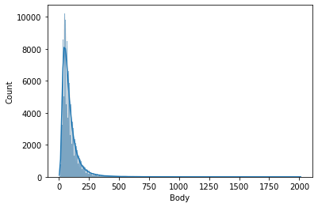

```python
sns.histplot(data=df_stack['Body'].str.len(), kde=True)
```

```
(0.0, 500.0)
```

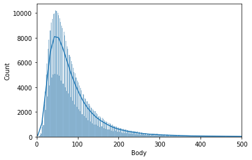

```python
ax = sns.histplot(data=df_stack['Body'].str.len(), kde=True)
ax.set_xlim([0,500])
```

Conservons la quantile de 95% de la longueur des questions.

```python
len_max = df_stack['Body'].str.len().quantile(0.95)
len_max
```

```
224.0
```

```python
X_train, X_test, y_train, y_test = train_test_split(df_stack['Body'], df_stack['Tags'], random_state=1, test_size=0.20)

tokenizer = Tokenizer(filters='')
tokenizer.fit_on_texts(X_train)
sequences = tokenizer.texts_to_sequences(X_train)
train_padded = pad_sequences(sequences, maxlen=int(len_max))
testing_sequences = tokenizer.texts_to_sequences(X_test)
test_padded = pad_sequences(testing_sequences, maxlen=int(len_max))

mlb = MultiLabelBinarizer().fit(df_stack['Tags'])
y_train = mlb.transform(y_train)
y_test = mlb.transform(y_test)
```

### CNN

```python
model = tf.keras.Sequential([
  tf.keras.layers.Embedding(29000, 10),
  tf.keras.layers.Conv1D(128, 3, activation='relu'),
  tf.keras.layers.BatchNormalization(),
  tf.keras.layers.Conv1D(256, 3, activation='relu'),
  tf.keras.layers.BatchNormalization(),
  tf.keras.layers.GlobalAveragePooling1D(),
  tf.keras.layers.Dense(256, activation='relu'),
  tf.keras.layers.Dropout(0.4),
  tf.keras.layers.Dense(128, activation='sigmoid')
])
model.compile(optimizer='adam', loss='binary_crossentropy', metrics=['accuracy'])
history = model.fit(train_padded, y_train, epochs=50,
                    batch_size=128,
                    validation_split=0.3,
                    callbacks=[tf.keras.callbacks.EarlyStopping('val_loss', patience=3)])
```

```python
pred_train = model.predict(train_padded)
pred_train[pred_train >= 0.5] = 1
pred_train[pred_train < 0.5] = 0
pred_test = model.predict(test_padded)
pred_test[pred_test >= 0.5] = 1
pred_test[pred_test < 0.5] = 0

print('Taux de succès du train {}'.format(accuracy_score(pred_train, y_train)))
print('Taux de succès du test {}'.format(accuracy_score(pred_test, y_test)))
print('f1-score du test {}'.format(f1_score(pred_test, y_test, average='micro')))
```

```
Taux de succès du train 0.474071947952545
Taux de succès du test 0.4209785801920241
f1-score du test 0.7270530894973153
```

### Dense

```python
model = tf.keras.Sequential([
  tf.keras.layers.Embedding(29000, 10),
  tf.keras.layers.Dense(128, activation='relu'),
  tf.keras.layers.BatchNormalization(),
  tf.keras.layers.Dense(256, activation='relu'),
  tf.keras.layers.BatchNormalization(),
  tf.keras.layers.GlobalAveragePooling1D(),
  tf.keras.layers.Dense(256, activation='relu'),
  tf.keras.layers.Dropout(0.4),
  tf.keras.layers.Dense(128, activation='sigmoid')
])
model.compile(optimizer='adam', loss='binary_crossentropy', metrics=['accuracy'])
history = model.fit(train_padded, y_train, epochs=50,
                    batch_size=128,
                    validation_data=(test_padded, y_test),
                    callbacks=[tf.keras.callbacks.EarlyStopping('val_loss', patience=3)])
```

```python
pred_train = model.predict(train_padded)
pred_train[pred_train >= 0.5] = 1
pred_train[pred_train < 0.5] = 0
pred_test = model.predict(test_padded)
pred_test[pred_test >= 0.5] = 1
pred_test[pred_test < 0.5] = 0

print('Taux de succès du train {}'.format(accuracy_score(pred_train, y_train)))
print('Taux de succès du test {}'.format(accuracy_score(pred_test, y_test)))
print('f1-score du test {}'.format(f1_score(pred_test, y_test, average='micro')))
```

```
Taux de succès du train 0.47026181310641363
Taux de succès du test 0.4292065778958387
f1-score du test 0.7310376015290747
```

### LSTM

```python
model = tf.keras.Sequential([
  tf.keras.layers.Embedding(29000, 10),
  tf.keras.layers.LSTM(128, dropout=0.4, return_sequences=True),
  tf.keras.layers.LSTM(256, dropout=0.4),
  tf.keras.layers.Dense(128, activation='sigmoid')
])
model.compile(optimizer='adam', loss='binary_crossentropy', metrics=['accuracy'])
history = model.fit(train_padded, y_train, epochs=50,
                    batch_size=128,
                    validation_split=0.3,
                    callbacks=[tf.keras.callbacks.EarlyStopping('val_loss', patience=3)])
```

```python
pred_train = model.predict(train_padded)
pred_train[pred_train >= 0.5] = 1
pred_train[pred_train < 0.5] = 0
pred_test = model.predict(test_padded)
pred_test[pred_test >= 0.5] = 1
pred_test[pred_test < 0.5] = 0

print('Taux de succès du train {}'.format(accuracy_score(pred_train, y_train)))
print('Taux de succès du test {}'.format(accuracy_score(pred_test, y_test)))
print('f1-score du test {}'.format(f1_score(pred_test, y_test, average='micro')))
```

```
Taux de succès du train 0.45589642286306026
Taux de succès du test 0.42046081289465687
f1-score du test 0.7203093079164558
```

### Tuning

Pour la recherche d'hyperparamètre, un random search est utilisé sur :

- Le nombre maximum de mots
- La taille utilisée pour l'embedding des mots
- Le nombre de Conv1D, la taille des kernels pour les CNN
- Le nombre de couches denses
- Le nombre de neurones par couche
- Le taux de dropout
- La taux d'apprentissage
- Le nombre d'instance par batch

```python
best_scores = [[0, 0, 0, 0] for x in range(3)]

for cpt in range(25):
  print("Itération n°", cpt + 1)
  list_layers = []

  max_words = random.randint(2,6)*5000
  max_words = max_words if max_words < 29000 else 29000
  max_len = random.randint(2,6)*50

  tokenizer = Tokenizer(max_words, filters='')
  tokenizer.fit_on_texts(X_train)
  sequences = tokenizer.texts_to_sequences(X_train)
  train_padded_tuning = pad_sequences(sequences, maxlen=int(max_len))
  testing_sequences = tokenizer.texts_to_sequences(X_test)
  test_padded_tuning = pad_sequences(testing_sequences, maxlen=int(max_len))

  len_emb = random.randint(2,4)*5
  list_layers.append(tf.keras.layers.Embedding(max_words, len_emb))

  list_pow_conv1d = []
  power2 = 8
  n_conv1d = random.randint(2, 3)

  for i in range(n_conv1d):
    power2 = random.randint(power2, power2+1) if power2 < 11 else 11
    power = np.power(2, power2)
    kernel = random.randint(2,4)
    list_pow_conv1d.append(power)
    list_layers.append(tf.keras.layers.Conv1D(power, kernel, activation='relu'))
    list_layers.append(tf.keras.layers.BatchNormalization())

  list_layers.append(tf.keras.layers.GlobalAveragePooling1D())

  list_pow_dense = []
  for i in range(random.randint(1, 3)):
    power2 = random.randint(power2-1, power2)
    power = np.power(2, power2)
    list_pow_dense.append((power, round(0.05*(power2+1),2)))
    list_layers.append(tf.keras.layers.Dense(power, activation='relu'))
    list_layers.append(tf.keras.layers.Dropout(0.05*(power2+1)))

  list_layers.append(tf.keras.layers.Dense(128, activation='sigmoid'))

  lr = 10**random.uniform(np.log10(1e-4), np.log10(1e-3))
  nb_batch = np.power(2, random.randint(4, 7))

  print("Max words, len : ({}, {}), Embedding : {}, Size kernel : {}".format(max_words, max_len, len_emb, kernel))
  print("List Conv1d : {}, List dense : {}, Learning rate : {}, Batch : {}".format(list_pow_conv1d, list_pow_dense, lr, nb_batch))

  model = tf.keras.Sequential(list_layers)
  model.compile(optimizer=tf.keras.optimizers.Adam(learning_rate=lr), loss='binary_crossentropy', metrics=['accuracy'])
  model.fit(train_padded_tuning, y_train, epochs=50,
            batch_size=nb_batch,
            verbose=0,
            validation_split=0.3,
            callbacks=[tf.keras.callbacks.EarlyStopping('val_loss', patience=3)])

  pred_train = model.predict(train_padded_tuning)
  pred_train[pred_train >= 0.5] = 1
  pred_train[pred_train < 0.5] = 0
  pred_test = model.predict(test_padded_tuning)
  pred_test[pred_test >= 0.5] = 1
  pred_test[pred_test < 0.5] = 0

  acc_train = accuracy_score(pred_train, y_train)
  acc_test = accuracy_score(pred_test, y_test)
  f1_test = f1_score(pred_test, y_test, average='micro')
  print('Train : {}, Test : {}, F1_score : {}'.format(acc_train, acc_test, f1_test))

  if acc_train > best_scores[0][1]:
    best_scores[0][0] = (max_words, max_len, kernel, len_emb, list_pow_conv1d, list_pow_dense, lr, nb_batch)
    best_scores[0][1] = acc_train
    best_scores[0][2] = acc_test
    best_scores[0][3] = f1_test
  if acc_test > best_scores[1][2]:
    best_scores[1][0] = (max_words, max_len, kernel, len_emb, list_pow_conv1d, list_pow_dense, lr, nb_batch)
    best_scores[1][1] = acc_train
    best_scores[1][2] = acc_test
    best_scores[1][3] = f1_test
  if f1_test > best_scores[2][3]:
    best_scores[2][0] = (max_words, max_len, kernel,len_emb, list_pow_conv1d, list_pow_dense, lr, nb_batch)
    best_scores[2][1] = acc_train
    best_scores[2][2] = acc_test
    best_scores[2][3] = f1_test

  print("-----------")

print("Meilleur taux de succès train :")
print("Combinaison : {}, Train : {}, Test : {}, f1-score : {}".format(best_scores[0][0], best_scores[0][1], best_scores[0][2], best_scores[0][3]))
print("Meilleur taux de succès test :")
print("Combinaison : {}, Train : {}, Test : {}, f1-score : {}".format(best_scores[1][0], best_scores[1][1], best_scores[1][2], best_scores[1][3]))
print("Meilleur F1_score test :")
print("Combinaison : {}, Train : {}, Test : {}, f1-score : {}".format(best_scores[2][0], best_scores[2][1], best_scores[2][2], best_scores[2][3]))
```

```
Itération n° 1
Max words, len : (29000, 250), Embedding : 15, Size kernel : 3
List Conv1d : [512, 1024], List dense : [(1024, 0.55)], Learning rate : 0.00024685470189141724, Batch : 128
Train : 0.5111546340694716, Test : 0.42440034667897303, F1_score : 0.7300447993428038
-----------
Itération n° 2
Max words, len : (10000, 250), Embedding : 10, Size kernel : 2
List Conv1d : [256, 256], List dense : [(128, 0.4)], Learning rate : 0.0007353901486369345, Batch : 64
Train : 0.4384834875396772, Test : 0.41572211654266517, F1_score : 0.7190664445971272
-----------
Itération n° 3
Max words, len : (20000, 150), Embedding : 20, Size kernel : 2
List Conv1d : [256, 512], List dense : [(512, 0.5)], Learning rate : 0.00011312705878954894, Batch : 64
Train : 0.4715731298259832, Test : 0.42006685951622524, F1_score : 0.7262444788257046
-----------
Itération n° 4
Max words, len : (20000, 250), Embedding : 10, Size kernel : 4
List Conv1d : [512, 1024, 2048], List dense : [(2048, 0.6), (1024, 0.55)], Learning rate : 0.00010858406144880602, Batch : 16
Train : 0.46666554107291597, Test : 0.41164751302860103, F1_score : 0.7325777225552783
-----------
Itération n° 5
Max words, len : (15000, 150), Embedding : 15, Size kernel : 3
List Conv1d : [256, 256, 256], List dense : [(128, 0.4)], Learning rate : 0.0001224576683324696, Batch : 16
Train : 0.43689640035118527, Test : 0.40926128113638666, F1_score : 0.7114792933597193
-----------
Itération n° 6
Max words, len : (29000, 200), Embedding : 10, Size kernel : 2
List Conv1d : [256, 512], List dense : [(512, 0.5), (512, 0.5)], Learning rate : 0.0006302842473630974, Batch : 16
Train : 0.4272359919857725, Test : 0.41080332721767615, F1_score : 0.7207193602635824
-----------
Itération n° 7
Max words, len : (29000, 150), Embedding : 10, Size kernel : 2
List Conv1d : [256, 512, 1024], List dense : [(512, 0.5), (256, 0.45), (256, 0.45)], Learning rate : 0.0001210099821029714, Batch : 16
Train : 0.43636455730397783, Test : 0.4115011874880407, F1_score : 0.7167147114867836
-----------
Itération n° 8
Max words, len : (10000, 150), Embedding : 10, Size kernel : 3
List Conv1d : [512, 1024, 1024], List dense : [(512, 0.5), (256, 0.45)], Learning rate : 0.00012213281111101134, Batch : 128
Train : 0.48371547241169716, Test : 0.39839942370248643, F1_score : 0.7130204328243436
-----------
```

[output cut: 76 more lines]

```
Max words, len : (15000, 100), Embedding : 10, Size kernel : 2
List Conv1d : [256, 256, 512], List dense : [(256, 0.45), (256, 0.45), (128, 0.4)], Learning rate : 0.0001330018122960862, Batch : 32
Train : 0.42215675018572296, Test : 0.3979829587024301, F1_score : 0.6997619857191432
-----------
Itération n° 25
Max words, len : (20000, 200), Embedding : 10, Size kernel : 4
List Conv1d : [512, 1024, 1024], List dense : [(1024, 0.55), (1024, 0.55)], Learning rate : 0.0005834010492256955, Batch : 128
Train : 0.4881474978050922, Test : 0.4168589534347107, F1_score : 0.7300597768152316
-----------
Meilleur taux de succès train :
Combinaison : (29000, 250, 3, 15, [512, 1024], [(1024, 0.55)], 0.00024685470189141724, 128), Train : 0.5111546340694716, Test : 0.42440034667897303, f1-score : 0.7300447993428038
Meilleur taux de succès test :
Combinaison : (29000, 250, 3, 15, [512, 1024], [(1024, 0.55)], 0.00024685470189141724, 128), Train : 0.5111546340694716, Test : 0.42440034667897303, f1-score : 0.7300447993428038
Meilleur F1_score test :
Combinaison : (20000, 250, 4, 10, [512, 1024, 2048], [(2048, 0.6), (1024, 0.55)], 0.00010858406144880602, 16), Train : 0.46666554107291597, Test : 0.41164751302860103, f1-score : 0.7325777225552783
```

```python
X_train, X_test, y_train, y_test = train_test_split(df_stack['Body'], df_stack['Tags'], random_state=1, test_size=0.20)

tokenizer = Tokenizer(25000, filters='')
tokenizer.fit_on_texts(X_train)
sequences = tokenizer.texts_to_sequences(X_train)
train_padded = pad_sequences(sequences, maxlen=250)
testing_sequences = tokenizer.texts_to_sequences(X_test)
test_padded = pad_sequences(testing_sequences, maxlen=250)

mlb = MultiLabelBinarizer().fit(df_stack['Tags'])
y_train = mlb.transform(y_train)
y_test = mlb.transform(y_test)

model = tf.keras.Sequential([
  tf.keras.layers.Embedding(25000, 10),
  tf.keras.layers.Conv1D(512, 4, activation='relu'),
  tf.keras.layers.BatchNormalization(),
  tf.keras.layers.Conv1D(1024, 4, activation='relu'),
  tf.keras.layers.BatchNormalization(),
  tf.keras.layers.Conv1D(2048, 4, activation='relu'),
  tf.keras.layers.BatchNormalization(),
  tf.keras.layers.GlobalAveragePooling1D(),
  tf.keras.layers.Dense(2048, activation='relu'),
  tf.keras.layers.Dropout(0.6),
  tf.keras.layers.Dense(1024, activation='relu'),
  tf.keras.layers.Dropout(0.55),
  tf.keras.layers.Dense(128, activation='sigmoid')
])
model.compile(optimizer=tf.keras.optimizers.Adam(learning_rate=0.00010858406144880602), loss='binary_crossentropy', metrics=['accuracy'])
history = model.fit(train_padded, y_train, epochs=50,
                    batch_size=16,
                    validation_split=0.3,
                    callbacks=[tf.keras.callbacks.EarlyStopping('val_loss', patience=3)])

PATH_SAVE = 'drive/My Drive/Colab Notebooks/OC/Projet 5/'

conv1d_ft_model = PATH_SAVE + 'conv1d_ft_model.sav'
model.save(conv1d_ft_model)


pred_train = model.predict(train_padded)
pred_train[pred_train >= 0.5] = 1
pred_train[pred_train < 0.5] = 0
pred_test = model.predict(test_padded)
pred_test[pred_test >= 0.5] = 1
pred_test[pred_test < 0.5] = 0

print('Taux de succès du train {}'.format(accuracy_score(pred_train, y_train)))
print('Taux de succès du test {}'.format(accuracy_score(pred_test, y_test)))
print('f1-score du test {}'.format(f1_score(pred_test, y_test, average='micro')))
```

```
INFO:tensorflow:Assets written to: drive/My Drive/Colab Notebooks/OC/Projet 5/conv1d_ft_model.sav/assets
Taux de succès du train 0.4598613268499133
Taux de succès du test 0.4072690026226039
f1-score du test 0.7302912424756101
```

```python
best_scores = [[0, 0, 0, 0] for x in range(3)]

for cpt in range(25):
  print("Itération n°", cpt + 1)
  list_layers = []

  max_words = random.randint(2,6)*5000
  max_words = max_words if max_words < 29000 else 29000
  max_len = random.randint(2,6)*50

  tokenizer = Tokenizer(max_words, filters='')
  tokenizer.fit_on_texts(X_train)
  sequences = tokenizer.texts_to_sequences(X_train)
  train_padded_tuning = pad_sequences(sequences, maxlen=int(max_len))
  testing_sequences = tokenizer.texts_to_sequences(X_test)
  test_padded_tuning = pad_sequences(testing_sequences, maxlen=int(max_len))

  len_emb = random.randint(2,4)*5
  list_layers.append(tf.keras.layers.Embedding(max_words, len_emb))

  list_pow_dense1 = []
  power2 = 8
  n_dense1 = random.randint(2, 3)

  for i in range(n_dense1):
    power2 = random.randint(power2, power2+1) if power2 < 11 else 11

    power = np.power(2, power2)
    list_pow_dense1.append(power)
    list_layers.append(tf.keras.layers.Dense(power, activation='relu'))
    list_layers.append(tf.keras.layers.BatchNormalization())

  list_layers.append(tf.keras.layers.GlobalAveragePooling1D())

  list_pow_dense = []
  for i in range(random.randint(1, 3)):
    power2 = random.randint(power2-1, power2)
    power = np.power(2, power2)
    list_pow_dense.append((power, round(0.05*(power2+1),2)))
    list_layers.append(tf.keras.layers.Dense(power, activation='relu'))
    list_layers.append(tf.keras.layers.Dropout(0.05*(power2+1)))

  list_layers.append(tf.keras.layers.Dense(128, activation='sigmoid'))

  lr = 10**random.uniform(np.log10(1e-4), np.log10(1e-3))
  nb_batch = np.power(2, random.randint(4, 7))

  print("Max words, len : ({}, {}), Embedding : {}".format(max_words, max_len, len_emb))
  print("List dense part 1 : {}, List dense part 2 : {}, Learning rate : {}, Batch : {}".format(list_pow_dense1, list_pow_dense, lr, nb_batch))

  model = tf.keras.Sequential(list_layers)
  model.compile(optimizer=tf.keras.optimizers.Adam(learning_rate=lr), loss='binary_crossentropy', metrics=['accuracy'])
  model.fit(train_padded_tuning, y_train, epochs=50,
            batch_size=nb_batch,
            verbose=0,
            validation_split=0.3,
            callbacks=[tf.keras.callbacks.EarlyStopping('val_loss', patience=3)])

  pred_train = model.predict(train_padded_tuning)
  pred_train[pred_train >= 0.5] = 1
  pred_train[pred_train < 0.5] = 0
  pred_test = model.predict(test_padded_tuning)
  pred_test[pred_test >= 0.5] = 1
  pred_test[pred_test < 0.5] = 0

  acc_train = accuracy_score(pred_train, y_train)
  acc_test = accuracy_score(pred_test, y_test)
  f1_test = f1_score(pred_test, y_test, average='micro')
  print('Train : {}, Test : {}, F1_score : {}'.format(acc_train, acc_test, f1_test))

  if acc_train > best_scores[0][1]:
    best_scores[0][0] = (max_words, max_len, len_emb, list_pow_dense1, list_pow_dense, lr, nb_batch)
    best_scores[0][1] = acc_train
    best_scores[0][2] = acc_test
    best_scores[0][3] = f1_test
  if acc_test > best_scores[1][2]:
    best_scores[1][0] = (max_words, max_len, len_emb, list_pow_dense1, list_pow_dense, lr, nb_batch)
    best_scores[1][1] = acc_train
    best_scores[1][2] = acc_test
    best_scores[1][3] = f1_test
  if f1_test > best_scores[2][3]:
    best_scores[2][0] = (max_words, max_len, len_emb, list_pow_dense1, list_pow_dense, lr, nb_batch)
    best_scores[2][1] = acc_train
    best_scores[2][2] = acc_test
    best_scores[2][3] = f1_test

  print("-----------")

print("Meilleur taux de succès train :")
print("Combinaison : {}, Train : {}, Test : {}, f1-score : {}".format(best_scores[0][0], best_scores[0][1], best_scores[0][2], best_scores[0][3]))
print("Meilleur taux de succès test :")
print("Combinaison : {}, Train : {}, Test : {}, f1-score : {}".format(best_scores[1][0], best_scores[1][1], best_scores[1][2], best_scores[1][3]))
print("Meilleur F1_score test :")
print("Combinaison : {}, Train : {}, Test : {}, f1-score : {}".format(best_scores[2][0], best_scores[2][1], best_scores[2][2], best_scores[2][3]))
```

```
Itération n° 1
Max words, len : (20000, 250), Embedding : 20
List dense part 1 : [512, 512], List dense part 2 : [(512, 0.5), (256, 0.45)], Learning rate : 0.000583354029683928, Batch : 128
Train : 0.46544708583777944, Test : 0.4254358812737076, F1_score : 0.7333792569288082
-----------
Itération n° 2
Max words, len : (29000, 100), Embedding : 20
List dense part 1 : [256, 512, 512], List dense part 2 : [(256, 0.45)], Learning rate : 0.00040954107121706136, Batch : 16
Train : 0.42187816573242387, Test : 0.40257532951386155, F1_score : 0.7047688518788684
-----------
Itération n° 3
Max words, len : (15000, 300), Embedding : 20
List dense part 1 : [256, 512, 1024], List dense part 2 : [(512, 0.5), (512, 0.5)], Learning rate : 0.0007919997342043656, Batch : 32
Train : 0.43290898448931814, Test : 0.41502425627230055, F1_score : 0.7260086525038356
-----------
Itération n° 4
Max words, len : (15000, 150), Embedding : 10
List dense part 1 : [512, 512, 1024], List dense part 2 : [(512, 0.5)], Learning rate : 0.00039200816516696225, Batch : 64
Train : 0.45501001778438127, Test : 0.42693290411174767, F1_score : 0.7245543333285527
-----------
Itération n° 5
Max words, len : (20000, 250), Embedding : 10
List dense part 1 : [512, 512, 512], List dense part 2 : [(512, 0.5)], Learning rate : 0.000793235944385968, Batch : 128
Train : 0.46495182458746986, Test : 0.43148025167992976, F1_score : 0.7343733054390378
-----------
Itération n° 6
Max words, len : (25000, 100), Embedding : 10
List dense part 1 : [256, 256, 512], List dense part 2 : [(512, 0.5), (512, 0.5), (256, 0.45)], Learning rate : 0.0001579909917939661, Batch : 128
Train : 0.44682413723239006, Test : 0.41060072262305414, F1_score : 0.7136351196783317
-----------
Itération n° 7
Max words, len : (10000, 250), Embedding : 15
List dense part 1 : [512, 1024], List dense part 2 : [(1024, 0.55), (512, 0.5)], Learning rate : 0.0002182912290691716, Batch : 32
Train : 0.4474122599671327, Test : 0.4251769976250239, F1_score : 0.7391816634608607
-----------
Itération n° 8
Max words, len : (25000, 200), Embedding : 15
List dense part 1 : [512, 1024], List dense part 2 : [(512, 0.5), (512, 0.5), (512, 0.5)], Learning rate : 0.0001411527202843592, Batch : 128
Train : 0.4689870781837419, Test : 0.42472676519253066, F1_score : 0.7311636599753327
-----------
```

[output cut: 76 more lines]

```
Max words, len : (10000, 300), Embedding : 15
List dense part 1 : [256, 256, 256], List dense part 2 : [(256, 0.45)], Learning rate : 0.0009344562347145613, Batch : 32
Train : 0.4308435199567772, Test : 0.4173879765428903, F1_score : 0.7201317905133799
-----------
Itération n° 25
Max words, len : (10000, 150), Embedding : 10
List dense part 1 : [512, 512, 512], List dense part 2 : [(256, 0.45)], Learning rate : 0.00014959367187037097, Batch : 64
Train : 0.43700333175750206, Test : 0.4148891865425526, F1_score : 0.7216848274488606
-----------
Meilleur taux de succès train :
Combinaison : (25000, 250, 10, [512, 512, 1024], [(1024, 0.55), (512, 0.5)], 0.00022231214926757387, 64), Train : 0.47693658404808537, Test : 0.43234694911247934, f1-score : 0.7438626024569631
Meilleur taux de succès test :
Combinaison : (25000, 250, 10, [512, 512, 1024], [(1024, 0.55), (512, 0.5)], 0.00022231214926757387, 64), Train : 0.47693658404808537, Test : 0.43234694911247934, f1-score : 0.7438626024569631
Meilleur F1_score test :
Combinaison : (25000, 250, 10, [512, 512, 1024], [(1024, 0.55), (512, 0.5)], 0.00022231214926757387, 64), Train : 0.47693658404808537, Test : 0.43234694911247934, f1-score : 0.7438626024569631
```

```python
X_train, X_test, y_train, y_test = train_test_split(df_stack['Body'], df_stack['Tags'], random_state=1, test_size=0.20)

tokenizer = Tokenizer(25000, filters='')
tokenizer.fit_on_texts(X_train)
sequences = tokenizer.texts_to_sequences(X_train)
train_padded = pad_sequences(sequences, maxlen=250)
testing_sequences = tokenizer.texts_to_sequences(X_test)
test_padded = pad_sequences(testing_sequences, maxlen=250)

mlb = MultiLabelBinarizer().fit(df_stack['Tags'])
y_train = mlb.transform(y_train)
y_test = mlb.transform(y_test)

model = tf.keras.Sequential([
  tf.keras.layers.Embedding(25000, 10),
  tf.keras.layers.Dense(512, activation='relu'),
  tf.keras.layers.BatchNormalization(),
  tf.keras.layers.Dense(512, activation='relu'),
  tf.keras.layers.BatchNormalization(),
  tf.keras.layers.Dense(1024, activation='relu'),
  tf.keras.layers.BatchNormalization(),
  tf.keras.layers.GlobalAveragePooling1D(),
  tf.keras.layers.Dense(1024, activation='relu'),
  tf.keras.layers.Dropout(0.55),
  tf.keras.layers.Dense(512, activation='relu'),
  tf.keras.layers.Dropout(0.5),
  tf.keras.layers.Dense(128, activation='sigmoid')
])
model.compile(optimizer=tf.keras.optimizers.Adam(learning_rate=0.00022231214926757387), loss='binary_crossentropy', metrics=['accuracy'])
history = model.fit(train_padded, y_train, epochs=50,
                    batch_size=64,
                    validation_split=0.3,
                    callbacks=[tf.keras.callbacks.EarlyStopping('val_loss', patience=3)])

PATH_SAVE = 'drive/My Drive/Colab Notebooks/OC/Projet 5/'

ann_ft_model = PATH_SAVE + 'ann_ft_model.sav'
model.save(ann_ft_model)

pred_train = model.predict(train_padded)
pred_train[pred_train >= 0.5] = 1
pred_train[pred_train < 0.5] = 0
pred_test = model.predict(test_padded)
pred_test[pred_test >= 0.5] = 1
pred_test[pred_test < 0.5] = 0

print('Taux de succès du train {}'.format(accuracy_score(pred_train, y_train)))
print('Taux de succès du test {}'.format(accuracy_score(pred_test, y_test)))
print('f1-score du test {}'.format(f1_score(pred_test, y_test, average='micro')))
```

```
INFO:tensorflow:Assets written to: drive/My Drive/Colab Notebooks/OC/Projet 5/ann_ft_model.sav/assets
```

```
INFO:tensorflow:Assets written to: drive/My Drive/Colab Notebooks/OC/Projet 5/ann_ft_model.sav/assets
```

```
Taux de succès du train 0.46715517435447196
Taux de succès du test 0.4294429499228977
f1-score du test 0.7418916698247037
```

```python
best_scores = [[0, 0, 0, 0] for x in range(3)]

for cpt in range(20):
  print("Itération n°", cpt + 1)
  list_layers = []

  max_words = random.randint(2,6)*5000
  max_words = max_words if max_words < 29000 else 29000
  max_len = random.randint(2,6)*50

  tokenizer = Tokenizer(max_words, filters='')
  tokenizer.fit_on_texts(X_train)
  sequences = tokenizer.texts_to_sequences(X_train)
  train_padded_tuning = pad_sequences(sequences, maxlen=int(max_len))
  testing_sequences = tokenizer.texts_to_sequences(X_test)
  test_padded_tuning = pad_sequences(testing_sequences, maxlen=int(max_len))

  len_emb = random.randint(2,4)*5
  list_layers.append(tf.keras.layers.Embedding(max_words, len_emb))

  list_pow_lstm = []
  n_layer = random.randint(0, 1)

  for i in range(n_layer):
    power2 = random.randint(7, 9)
    power = np.power(2, power2)
    list_pow_lstm.append((power, 0.05*(power2+1)))
    list_layers.append(tf.keras.layers.LSTM(power, dropout=0.05*(power2+1), return_sequences=True))

  power2 = random.randint(7, 9)
  power = np.power(2, power2)
  list_pow_lstm.append((power, 0.05*(power2+1)))
  list_layers.append(tf.keras.layers.LSTM(power, dropout=0.05*(power2+1)))
  list_layers.append(tf.keras.layers.Dense(128, activation='sigmoid'))

  lr = 10**random.uniform(np.log10(1e-4), np.log10(1e-3))
  nb_batch = np.power(2, random.randint(4, 7))

  print("Max words, len : ({}, {}), Embedding : {}".format(max_words, max_len, len_emb))
  print("List LSTM : {}, Learning rate : {}, Batch : {}".format(list_pow_lstm, lr, nb_batch))

  model = tf.keras.Sequential(list_layers)
  model.compile(optimizer=tf.keras.optimizers.Adam(learning_rate=lr), loss='binary_crossentropy', metrics=['accuracy'])
  model.fit(train_padded_tuning, y_train, epochs=50,
            batch_size=nb_batch,
            verbose=0,
            validation_split=0.3,
            callbacks=[tf.keras.callbacks.EarlyStopping('val_loss', patience=3)])

  pred_train = model.predict(train_padded_tuning)
  pred_train[pred_train >= 0.5] = 1
  pred_train[pred_train < 0.5] = 0
  pred_test = model.predict(test_padded_tuning)
  pred_test[pred_test >= 0.5] = 1
  pred_test[pred_test < 0.5] = 0

  acc_train = accuracy_score(pred_train, y_train)
  acc_test = accuracy_score(pred_test, y_test)
  f1_test = f1_score(pred_test, y_test, average='micro')
  print('Train : {}, Test : {}, F1_score : {}'.format(acc_train, acc_test, f1_test))

  if acc_train > best_scores[0][1]:
    best_scores[0][0] = (max_words, max_len, len_emb, list_pow_lstm, lr, nb_batch)
    best_scores[0][1] = acc_train
    best_scores[0][2] = acc_test
    best_scores[0][3] = f1_test
  if acc_test > best_scores[1][2]:
    best_scores[1][0] = (max_words, max_len, len_emb, list_pow_lstm, lr, nb_batch)
    best_scores[1][1] = acc_train
    best_scores[1][2] = acc_test
    best_scores[1][3] = f1_test
  if f1_test > best_scores[2][3]:
    best_scores[2][0] = (max_words, max_len, len_emb, list_pow_lstm, lr, nb_batch)
    best_scores[2][1] = acc_train
    best_scores[2][2] = acc_test
    best_scores[2][3] = f1_test

  print("-----------")

print("Meilleur taux de succès train :")
print("Combinaison : {}, Train : {}, Test : {}, f1-score : {}".format(best_scores[0][0], best_scores[0][1], best_scores[0][2], best_scores[0][3]))
print("Meilleur taux de succès test :")
print("Combinaison : {}, Train : {}, Test : {}, f1-score : {}".format(best_scores[1][0], best_scores[1][1], best_scores[1][2], best_scores[1][3]))
print("Meilleur F1_score test :")
print("Combinaison : {}, Train : {}, Test : {}, f1-score : {}".format(best_scores[2][0], best_scores[2][1], best_scores[2][2], best_scores[2][3]))
```

```
Itération n° 1
Max words, len : (29000, 300), Embedding : 20
List LSTM : [(128, 0.4), (512, 0.5)], Learning rate : 0.0007159028887238086, Batch : 32
Train : 0.48585128655365706, Test : 0.4349245297885033, F1_score : 0.7339576516081471
-----------
Itération n° 2
Max words, len : (29000, 100), Embedding : 10
List LSTM : [(512, 0.5)], Learning rate : 0.0006076370727099922, Batch : 64
Train : 0.37421208437450754, Test : 0.35687673761579414, F1_score : 0.656529279362385
-----------
Itération n° 3
Max words, len : (25000, 200), Embedding : 15
List LSTM : [(128, 0.4), (512, 0.5)], Learning rate : 0.00010313066642616993, Batch : 64
Train : 0.4627006370860629, Test : 0.4216314172191394, F1_score : 0.7228526146742243
-----------
Itération n° 4
Max words, len : (15000, 200), Embedding : 20
List LSTM : [(256, 0.45), (256, 0.45)], Learning rate : 0.00013698965504060445, Batch : 64
Train : 0.0, Test : 0.0, F1_score : 0.0
-----------
Itération n° 5
Max words, len : (20000, 300), Embedding : 20
List LSTM : [(512, 0.5)], Learning rate : 0.00029085000961699394, Batch : 16
Train : 0.46361236802413275, Test : 0.42709048546312034, F1_score : 0.7295159163684309
-----------
Itération n° 6
Max words, len : (10000, 300), Embedding : 10
List LSTM : [(512, 0.5), (512, 0.5)], Learning rate : 0.00023061198628155082, Batch : 64
Train : 0.0, Test : 0.0, F1_score : 0.0
-----------
Itération n° 7
Max words, len : (20000, 200), Embedding : 20
List LSTM : [(256, 0.45)], Learning rate : 0.00043519801312252453, Batch : 64
Train : 0.46526136286891334, Test : 0.4283173688416645, F1_score : 0.729712242228592
-----------
Itération n° 8
Max words, len : (15000, 200), Embedding : 10
List LSTM : [(256, 0.45), (256, 0.45)], Learning rate : 0.0009624599329474051, Batch : 128
Train : 0.4018425969699016, Test : 0.3881904032957014, F1_score : 0.6811811591006015
-----------
```

[output cut: 28 more lines]

[output not shown]

```python
X_train, X_test, y_train, y_test = train_test_split(df_stack['Body'], df_stack['Tags'], random_state=1, test_size=0.20)

tokenizer = Tokenizer(25000, filters='')
tokenizer.fit_on_texts(X_train)
sequences = tokenizer.texts_to_sequences(X_train)
train_padded = pad_sequences(sequences, maxlen=250)
testing_sequences = tokenizer.texts_to_sequences(X_test)
test_padded = pad_sequences(testing_sequences, maxlen=250)

mlb = MultiLabelBinarizer().fit(df_stack['Tags'])
y_train = mlb.transform(y_train)
y_test = mlb.transform(y_test)

model = tf.keras.Sequential([
  tf.keras.layers.Embedding(25000, 20),
  tf.keras.layers.LSTM(128, dropout=0.4, return_sequences=True),
  tf.keras.layers.LSTM(512, dropout=0.5),
  tf.keras.layers.Dense(128, activation='sigmoid')
])
model.compile(optimizer=tf.keras.optimizers.Adam(learning_rate=0.0007159028887238086), loss='binary_crossentropy', metrics=['accuracy'])
history = model.fit(train_padded, y_train, epochs=50,
                    batch_size=32,
                    validation_split=0.3,
                    callbacks=[tf.keras.callbacks.EarlyStopping('val_loss', patience=3)])

PATH_SAVE = 'drive/My Drive/Colab Notebooks/OC/Projet 5/'

lstm_ft_model = PATH_SAVE + 'lstm_ft_model.sav'
model.save(lstm_ft_model)

pred_train = model.predict(train_padded)
pred_train[pred_train >= 0.5] = 1
pred_train[pred_train < 0.5] = 0
pred_test = model.predict(test_padded)
pred_test[pred_test >= 0.5] = 1
pred_test[pred_test < 0.5] = 0

print('Taux de succès du train {}'.format(accuracy_score(pred_train, y_train)))
print('Taux de succès du test {}'.format(accuracy_score(pred_test, y_test)))
print('f1-score du test {}'.format(f1_score(pred_test, y_test, average='micro')))
```

[output not shown]

```
INFO:tensorflow:Assets written to: drive/My Drive/Colab Notebooks/OC/Projet 5/lstm_ft_model.sav/assets
```

```
INFO:tensorflow:Assets written to: drive/My Drive/Colab Notebooks/OC/Projet 5/lstm_ft_model.sav/assets
```

```
Taux de succès du train 0.48750309538281444
Taux de succès du test 0.4368155060049751
f1-score du test 0.734658829114366
```

### Stacking

```python
PATH_SAVE = 'drive/My Drive/Colab Notebooks/OC/Projet 5/'
conv_model = tf.keras.models.load_model(PATH_SAVE+'conv1d_ft_model.sav')
dense_model = tf.keras.models.load_model(PATH_SAVE+'ann_ft_model.sav')
lstm_model = tf.keras.models.load_model(PATH_SAVE+'lstm_ft_model.sav')
```

```python
X_train, X_test, y_train, y_test = train_test_split(df_stack['Body'], df_stack['Tags'], random_state=1, test_size=0.20)

tokenizer = Tokenizer(25000, filters='')
tokenizer.fit_on_texts(X_train)
sequences = tokenizer.texts_to_sequences(X_train)
train_padded = pad_sequences(sequences, maxlen=250)
testing_sequences = tokenizer.texts_to_sequences(X_test)
test_padded = pad_sequences(testing_sequences, maxlen=250)

mlb = MultiLabelBinarizer().fit(df_stack['Tags'])
y_train = mlb.transform(y_train)
y_test = mlb.transform(y_test)

PATH_SAVE = 'drive/My Drive/Colab Notebooks/OC/Projet 5/files/'
pickle.dump(tokenizer, open(PATH_SAVE+"Tokenizer", "wb"))
```

```python
train_conv_proba = conv_model.predict(train_padded)
train_dense_proba = dense_model.predict(train_padded)
train_lstm_proba = lstm_model.predict(train_padded)
test_conv_proba = conv_model.predict(test_padded)
test_dense_proba = dense_model.predict(test_padded)
test_lstm_proba = lstm_model.predict(test_padded)
list_train_proba = [train_conv_proba, train_dense_proba, train_lstm_proba]
list_test_proba = [test_conv_proba, test_dense_proba, test_lstm_proba]
```

```python
best_preds = weighted_batch(list_train_proba,
                            y_train,
                            list_test_proba,
                            y_test,
                            min_weight=0,
                            step=0.05,
                            min_threshold=0.2,
                            max_threshold=0.6)

print("Meilleur taux de succès train :")
print("Combinaison : {}, Train : {}, Test : {}, f1-score : {}".format(best_preds[0][0], best_preds[0][1], best_preds[0][2], best_preds[0][3]))
print("Meilleur taux de succès test :")
print("Combinaison : {}, Train : {}, Test : {}, f1-score : {}".format(best_preds[1][0], best_preds[1][1], best_preds[1][2], best_preds[1][3]))
print("Meilleur F1_score test :")
print("Combinaison : {}, Train : {}, Test : {}, f1-score : {}".format(best_preds[2][0], best_preds[2][1], best_preds[2][2], best_preds[2][3]))
```

```
Meilleur taux de succès train :
Combinaison : (0.5, 0.3, 0.15, 0.55), Train : 0.49826377163953983, Test : 0.44496471303310337, f1-score : 0.7468934078457758
Meilleur taux de succès test :
Combinaison : (0.5, 0.15, 0.4, 0.45), Train : 0.4956298822628937, Test : 0.4470020147901354, f1-score : 0.7482481450948064
Meilleur F1_score test :
Combinaison : (0.4, 0.2, 0.4, 0.4), Train : 0.48169221764480763, Test : 0.4325833211395383, f1-score : 0.7546733872659274
```